# marketing-campaign-notebook

```python
import pandas as pd
import numpy as np
import matplotlib.pyplot as plt
import seaborn as sns
from sklearn.model_selection import train_test_split
from sklearn.linear_model import LinearRegression
from sklearn.metrics import mean_squared_error, r2_score
import statsmodels.api as sm

sns.set(style='whitegrid')
pd.set_option('display.max_columns', None) # Parameter to displays all the columns
pd.set_option('display.float_format', '{:.2f}'.format)

# New custom color palette (multi-category plots)
colors = ["#430C05", "#D46F4D", "#FFBF66", "#08C5D1", "#00353F", "#A7001E", "#606C5A"]
main_num_color = colors[4]

# Binary palette for y (yes/no) plots
binary_color = ["#606C5A", "#A7001E"]  # no, yes
palette_y = {"no": binary_color[0], "yes": binary_color[1]}
```

```python
import pandas as pd

# Read line by line to avoid quote-parsing issues
with open('/content/TeleCom_Data.csv', 'r', encoding='utf-8') as f:
    lines = f.read().splitlines()

# Clean each line: remove surrounding/embedded extra quotes
clean_lines = [line.replace('""', '"').strip('"') for line in lines if line.strip()]

# First line = headers, rest = data
header = [c.strip('"') for c in clean_lines[0].split(';')]
data = [row.split(';') for row in clean_lines[1:]]

# Some rows may have a trailing empty field if line ends with ';' — trim to header length
data = [row[:len(header)] for row in data]

df = pd.DataFrame(data, columns=header)

# Strip remaining quotes from cells
for col in df.columns:
    df[col] = df[col].str.strip('"')

df = df.reset_index(drop=True)

# Convert numeric columns
num_cols = ['age', 'duration', 'campaign', 'pdays', 'previous',
            'emp.var.rate', 'cons.price.idx', 'cons.conf.idx',
            'euribor3m', 'nr.employed']
for col in num_cols:
    if col in df.columns:
        df[col] = pd.to_numeric(df[col], errors='coerce')

print(f'Shape: {df.shape}')
print(f'Columns: {list(df.columns)}')
df.head()
```

```
Shape: (41180, 21)
Columns: ['age', 'job', 'marital', 'education', 'default', 'housing', 'loan', 'contact', 'month', 'day_of_week', 'duration', 'campaign', 'pdays', 'previous', 'poutcome', 'emp.var.rate', 'cons.price.idx', 'cons.conf.idx', 'euribor3m', 'nr.employed', 'y']
```

|  | age | job | marital | education | default | housing | loan | contact | month | day_of_week | duration | campaign | pdays | previous | poutcome | emp.var.rate | cons.price.idx | cons.conf.idx | euribor3m | nr.employed | y |
| --- | --- | --- | --- | --- | --- | --- | --- | --- | --- | --- | --- | --- | --- | --- | --- | --- | --- | --- | --- | --- | --- |
| 0 | 40 | admin. | married | basic.6y | no | no | no | telephone | may | mon | 151 | 1 | 999 | 0 | nonexistent | 1.10 | 93.99 | -36.40 | 4.86 | 5191.00 | no |
| 1 | 56 | services | married | high.school | no | no | yes | telephone | may | mon | 307 | 1 | 999 | 0 | nonexistent | 1.10 | 93.99 | -36.40 | 4.86 | 5191.00 | no |
| 2 | 45 | services | married | basic.9y | unknown | no | no | telephone | may | mon | 198 | 1 | 999 | 0 | nonexistent | 1.10 | 93.99 | -36.40 | 4.86 | 5191.00 | no |
| 3 | 59 | admin. | married | professional.course | no | no | no | telephone | may | mon | 139 | 1 | 999 | 0 | nonexistent | 1.10 | 93.99 | -36.40 | 4.86 | 5191.00 | no |
| 4 | 41 | blue-collar | married | unknown | unknown | no | no | telephone | may | mon | 217 | 1 | 999 | 0 | nonexistent | 1.10 | 93.99 | -36.40 | 4.86 | 5191.00 | no |

```python
df.head()
```

|  | age | job | marital | education | default | housing | loan | contact | month | day_of_week | duration | campaign | pdays | previous | poutcome | emp.var.rate | cons.price.idx | cons.conf.idx | euribor3m | nr.employed | y |
| --- | --- | --- | --- | --- | --- | --- | --- | --- | --- | --- | --- | --- | --- | --- | --- | --- | --- | --- | --- | --- | --- |
| 0 | 40 | admin. | married | basic.6y | no | no | no | telephone | may | mon | 151 | 1 | 999 | 0 | nonexistent | 1.10 | 93.99 | -36.40 | 4.86 | 5191.00 | no |
| 1 | 56 | services | married | high.school | no | no | yes | telephone | may | mon | 307 | 1 | 999 | 0 | nonexistent | 1.10 | 93.99 | -36.40 | 4.86 | 5191.00 | no |
| 2 | 45 | services | married | basic.9y | unknown | no | no | telephone | may | mon | 198 | 1 | 999 | 0 | nonexistent | 1.10 | 93.99 | -36.40 | 4.86 | 5191.00 | no |
| 3 | 59 | admin. | married | professional.course | no | no | no | telephone | may | mon | 139 | 1 | 999 | 0 | nonexistent | 1.10 | 93.99 | -36.40 | 4.86 | 5191.00 | no |
| 4 | 41 | blue-collar | married | unknown | unknown | no | no | telephone | may | mon | 217 | 1 | 999 | 0 | nonexistent | 1.10 | 93.99 | -36.40 | 4.86 | 5191.00 | no |

```python
df.shape
```

```
(41180, 21)
```

```python
df.describe()
```

|  | age | duration | campaign | pdays | previous | emp.var.rate | cons.price.idx | cons.conf.idx | euribor3m | nr.employed |
| --- | --- | --- | --- | --- | --- | --- | --- | --- | --- | --- |
| count | 41180.00 | 41180.00 | 41180.00 | 41180.00 | 41180.00 | 41180.00 | 41180.00 | 41180.00 | 41180.00 | 41180.00 |
| mean | 40.02 | 258.28 | 2.57 | 962.52 | 0.17 | 0.08 | 93.58 | -40.50 | 3.62 | 5167.05 |
| std | 10.42 | 259.30 | 2.77 | 186.81 | 0.49 | 1.57 | 0.58 | 4.63 | 1.73 | 72.23 |
| min | 17.00 | 0.00 | 1.00 | 0.00 | 0.00 | -3.40 | 92.20 | -50.80 | 0.63 | 4963.60 |
| 25% | 32.00 | 102.00 | 1.00 | 999.00 | 0.00 | -1.80 | 93.08 | -42.70 | 1.34 | 5099.10 |
| 50% | 38.00 | 180.00 | 2.00 | 999.00 | 0.00 | 1.10 | 93.75 | -41.80 | 4.86 | 5191.00 |
| 75% | 47.00 | 319.00 | 3.00 | 999.00 | 0.00 | 1.40 | 93.99 | -36.40 | 4.96 | 5228.10 |
| max | 98.00 | 4918.00 | 56.00 | 999.00 | 7.00 | 1.40 | 94.77 | -26.90 | 5.04 | 5228.10 |

```python
df.info()
```

```
<class 'pandas.core.frame.DataFrame'>
RangeIndex: 41180 entries, 0 to 41179
Data columns (total 21 columns):
 #   Column          Non-Null Count  Dtype
---  ------          --------------  -----
 0   age             41180 non-null  int64
 1   job             41180 non-null  object
 2   marital         41180 non-null  object
 3   education       41180 non-null  object
 4   default         41180 non-null  object
 5   housing         41180 non-null  object
 6   loan            41180 non-null  object
 7   contact         41180 non-null  object
 8   month           41180 non-null  object
 9   day_of_week     41180 non-null  object
 10  duration        41180 non-null  int64
 11  campaign        41180 non-null  int64
 12  pdays           41180 non-null  int64
 13  previous        41180 non-null  int64
 14  poutcome        41180 non-null  object
 15  emp.var.rate    41180 non-null  float64
 16  cons.price.idx  41180 non-null  float64
 17  cons.conf.idx   41180 non-null  float64
 18  euribor3m       41180 non-null  float64
 19  nr.employed     41180 non-null  float64
 20  y               41180 non-null  object
dtypes: float64(5), int64(5), object(11)
memory usage: 6.6+ MB
```

```python
print(df[num_cols].describe())
```

```
           age  duration  campaign    pdays  previous  emp.var.rate  \
count 41180.00  41180.00  41180.00 41180.00  41180.00      41180.00
mean     40.02    258.28      2.57   962.52      0.17          0.08
std      10.42    259.30      2.77   186.81      0.49          1.57
min      17.00      0.00      1.00     0.00      0.00         -3.40
25%      32.00    102.00      1.00   999.00      0.00         -1.80
50%      38.00    180.00      2.00   999.00      0.00          1.10
75%      47.00    319.00      3.00   999.00      0.00          1.40
max      98.00   4918.00     56.00   999.00      7.00          1.40

       cons.price.idx  cons.conf.idx  euribor3m  nr.employed
count        41180.00       41180.00   41180.00     41180.00
mean            93.58         -40.50       3.62      5167.05
std              0.58           4.63       1.73        72.23
min             92.20         -50.80       0.63      4963.60
25%             93.08         -42.70       1.34      5099.10
50%             93.75         -41.80       4.86      5191.00
75%             93.99         -36.40       4.96      5228.10
max             94.77         -26.90       5.04      5228.10
```

```python
print("Duplicate row (without the first occurence: )", df.duplicated().sum())

duplicated_rows = df[df.duplicated(keep=False)]

print("Indexes Involved: ", duplicated_rows.index.tolist())

duplicated_rows
```

```
Duplicate row (without the first occurence: ) 12
Indexes Involved:  [1261, 1262, 12256, 12257, 14151, 14230, 16815, 16952, 18460, 18461, 20068, 20212, 20527, 20530, 25179, 25213, 28472, 28473, 32501, 32512, 36946, 36947, 38251, 38277]
```

|  | age | job | marital | education | default | housing | loan | contact | month | day_of_week | duration | campaign | pdays | previous | poutcome | emp.var.rate | cons.price.idx | cons.conf.idx | euribor3m | nr.employed | y |
| --- | --- | --- | --- | --- | --- | --- | --- | --- | --- | --- | --- | --- | --- | --- | --- | --- | --- | --- | --- | --- | --- |
| 1261 | 39 | blue-collar | married | basic.6y | no | no | no | telephone | may | thu | 124 | 1 | 999 | 0 | nonexistent | 1.10 | 93.99 | -36.40 | 4.86 | 5191.00 | no |
| 1262 | 39 | blue-collar | married | basic.6y | no | no | no | telephone | may | thu | 124 | 1 | 999 | 0 | nonexistent | 1.10 | 93.99 | -36.40 | 4.86 | 5191.00 | no |
| 12256 | 36 | retired | married | unknown | no | no | no | telephone | jul | thu | 88 | 1 | 999 | 0 | nonexistent | 1.40 | 93.92 | -42.70 | 4.97 | 5228.10 | no |
| 12257 | 36 | retired | married | unknown | no | no | no | telephone | jul | thu | 88 | 1 | 999 | 0 | nonexistent | 1.40 | 93.92 | -42.70 | 4.97 | 5228.10 | no |
| 14151 | 27 | technician | single | professional.course | no | no | no | cellular | jul | mon | 331 | 2 | 999 | 0 | nonexistent | 1.40 | 93.92 | -42.70 | 4.96 | 5228.10 | no |
| 14230 | 27 | technician | single | professional.course | no | no | no | cellular | jul | mon | 331 | 2 | 999 | 0 | nonexistent | 1.40 | 93.92 | -42.70 | 4.96 | 5228.10 | no |
| 16815 | 47 | technician | divorced | high.school | no | yes | no | cellular | jul | thu | 43 | 3 | 999 | 0 | nonexistent | 1.40 | 93.92 | -42.70 | 4.96 | 5228.10 | no |
| 16952 | 47 | technician | divorced | high.school | no | yes | no | cellular | jul | thu | 43 | 3 | 999 | 0 | nonexistent | 1.40 | 93.92 | -42.70 | 4.96 | 5228.10 | no |
| 18460 | 32 | technician | single | professional.course | no | yes | no | cellular | jul | thu | 128 | 1 | 999 | 0 | nonexistent | 1.40 | 93.92 | -42.70 | 4.97 | 5228.10 | no |
| 18461 | 32 | technician | single | professional.course | no | yes | no | cellular | jul | thu | 128 | 1 | 999 | 0 | nonexistent | 1.40 | 93.92 | -42.70 | 4.97 | 5228.10 | no |
| 20068 | 55 | services | married | high.school | unknown | no | no | cellular | aug | mon | 33 | 1 | 999 | 0 | nonexistent | 1.40 | 93.44 | -36.10 | 4.96 | 5228.10 | no |
| 20212 | 55 | services | married | high.school | unknown | no | no | cellular | aug | mon | 33 | 1 | 999 | 0 | nonexistent | 1.40 | 93.44 | -36.10 | 4.96 | 5228.10 | no |
| 20527 | 41 | technician | married | professional.course | no | yes | no | cellular | aug | tue | 127 | 1 | 999 | 0 | nonexistent | 1.40 | 93.44 | -36.10 | 4.97 | 5228.10 | no |
| 20530 | 41 | technician | married | professional.course | no | yes | no | cellular | aug | tue | 127 | 1 | 999 | 0 | nonexistent | 1.40 | 93.44 | -36.10 | 4.97 | 5228.10 | no |
| 25179 | 39 | admin. | married | university.degree | no | no | no | cellular | nov | tue | 123 | 2 | 999 | 0 | nonexistent | -0.10 | 93.20 | -42.00 | 4.15 | 5195.80 | no |
| 25213 | 39 | admin. | married | university.degree | no | no | no | cellular | nov | tue | 123 | 2 | 999 | 0 | nonexistent | -0.10 | 93.20 | -42.00 | 4.15 | 5195.80 | no |
| 28472 | 24 | services | single | high.school | no | yes | no | cellular | apr | tue | 114 | 1 | 999 | 0 | nonexistent | -1.80 | 93.08 | -47.10 | 1.42 | 5099.10 | no |
| 28473 | 24 | services | single | high.school | no | yes | no | cellular | apr | tue | 114 | 1 | 999 | 0 | nonexistent | -1.80 | 93.08 | -47.10 | 1.42 | 5099.10 | no |
| 32501 | 35 | admin. | married | university.degree | no | yes | no | cellular | may | fri | 348 | 4 | 999 | 0 | nonexistent | -1.80 | 92.89 | -46.20 | 1.31 | 5099.10 | no |
| 32512 | 35 | admin. | married | university.degree | no | yes | no | cellular | may | fri | 348 | 4 | 999 | 0 | nonexistent | -1.80 | 92.89 | -46.20 | 1.31 | 5099.10 | no |
| 36946 | 45 | admin. | married | university.degree | no | no | no | cellular | jul | thu | 252 | 1 | 999 | 0 | nonexistent | -2.90 | 92.47 | -33.60 | 1.07 | 5076.20 | yes |
| 36947 | 45 | admin. | married | university.degree | no | no | no | cellular | jul | thu | 252 | 1 | 999 | 0 | nonexistent | -2.90 | 92.47 | -33.60 | 1.07 | 5076.20 | yes |
| 38251 | 71 | retired | single | university.degree | no | no | no | telephone | oct | tue | 120 | 1 | 999 | 0 | nonexistent | -3.40 | 92.43 | -26.90 | 0.74 | 5017.50 | no |
| 38277 | 71 | retired | single | university.degree | no | no | no | telephone | oct | tue | 120 | 1 | 999 | 0 | nonexistent | -3.40 | 92.43 | -26.90 | 0.74 | 5017.50 | no |

```python
before = df.shape[0]
df = df.drop_duplicates()
after = df.shape[0]

print("Duplicates removed:", before - after)
```

```
Duplicates removed: 12
```

```python
print("Duplicate row (without the first occurence: )", df.duplicated().sum())
```

```
Duplicate row (without the first occurence: ) 0
```

```python
import numpy as np

df['previously_contacted'] = np.where(df['pdays'] != 999, 1, 0)
df['pdays'] = df['pdays'].replace(999, np.nan)
```

```python
df.describe()
```

|  | age | duration | campaign | pdays | previous | emp.var.rate | cons.price.idx | cons.conf.idx | euribor3m | nr.employed | previously_contacted |
| --- | --- | --- | --- | --- | --- | --- | --- | --- | --- | --- | --- |
| count | 41168.00 | 41168.00 | 41168.00 | 1513.00 | 41168.00 | 41168.00 | 41168.00 | 41168.00 | 41168.00 | 41168.00 | 41168.00 |
| mean | 40.02 | 258.31 | 2.57 | 6.02 | 0.17 | 0.08 | 93.58 | -40.50 | 3.62 | 5167.05 | 0.04 |
| std | 10.42 | 259.33 | 2.77 | 3.83 | 0.49 | 1.57 | 0.58 | 4.63 | 1.73 | 72.23 | 0.19 |
| min | 17.00 | 0.00 | 1.00 | 0.00 | 0.00 | -3.40 | 92.20 | -50.80 | 0.63 | 4963.60 | 0.00 |
| 25% | 32.00 | 102.00 | 1.00 | 3.00 | 0.00 | -1.80 | 93.08 | -42.70 | 1.34 | 5099.10 | 0.00 |
| 50% | 38.00 | 180.00 | 2.00 | 6.00 | 0.00 | 1.10 | 93.75 | -41.80 | 4.86 | 5191.00 | 0.00 |
| 75% | 47.00 | 319.00 | 3.00 | 7.00 | 0.00 | 1.40 | 93.99 | -36.40 | 4.96 | 5228.10 | 0.00 |
| max | 98.00 | 4918.00 | 56.00 | 27.00 | 7.00 | 1.40 | 94.77 | -26.90 | 5.04 | 5228.10 | 1.00 |

```python
inconsistent_1 = df[(df['previous'] == 0) & (df['pdays'].notna())]
inconsistent_2 = df[(df['previous'] > 0) & (df['pdays'].isna())]

print("previous = 0 but pdays is not NaN:", inconsistent_1.shape[0])
print("previous > 0 but pdays is NaN:", inconsistent_2.shape[0])
```

```
previous = 0 but pdays is not NaN: 0
previous > 0 but pdays is NaN: 4108
```

```python
df['y'].value_counts()
df['y'].value_counts(normalize=True) * 100
```

| y | proportion |
| --- | --- |
| no | 88.74 |
| yes | 11.26 |

**dtype:** float64

```python
# Check the state of y before splitting
print('y dtype:', df['y'].dtype)
print('y value_counts (with NaN):')
print(df['y'].value_counts(dropna=False))
print()
print(f'Total rows: {len(df)}')
print(f'Rows with y=None or NaN: {df["y"].isna().sum()}')
```

```
y dtype: object
y value_counts (with NaN):
y
no     36531
yes     4637
Name: count, dtype: int64

Total rows: 41168
Rows with y=None or NaN: 0
```

```python
# Drop rows where the target is missing — they cannot be used for supervised learning
before = len(df)
df = df.dropna(subset=['y']).copy()
df = df[df['y'].isin(['yes', 'no'])].reset_index(drop=True)
after = len(df)
print(f'Dropped {before - after} rows with invalid y values. New shape: {df.shape}')
```

```
Dropped 0 rows with invalid y values. New shape: (41168, 22)
```

```python
from sklearn.model_selection import train_test_split

train_df, test_df = train_test_split(
    df,
    test_size=0.2,
    random_state=42,
    stratify=df['y']
)
```

```python
print("Target distribution in FULL dataset (%):")
print(df['y'].value_counts(normalize=True).mul(100).round(2))
print("\nTarget distribution in TRAIN dataset (%):")
print(train_df['y'].value_counts(normalize=True).mul(100).round(2))
print("\nTarget distribution in TEST dataset (%):")
print(test_df['y'].value_counts(normalize=True).mul(100).round(2))
```

```
Target distribution in FULL dataset (%):
y
no    88.74
yes   11.26
Name: proportion, dtype: float64

Target distribution in TRAIN dataset (%):
y
no    88.74
yes   11.26
Name: proportion, dtype: float64

Target distribution in TEST dataset (%):
y
no    88.74
yes   11.26
Name: proportion, dtype: float64
```

# EDA TRAIN **DATASET**

```python
train_df.shape
```

```
(32934, 22)
```

```python
train_df.head()
```

|  | age | job | marital | education | default | housing | loan | contact | month | day_of_week | duration | campaign | pdays | previous | poutcome | emp.var.rate | cons.price.idx | cons.conf.idx | euribor3m | nr.employed | y | previously_contacted |
| --- | --- | --- | --- | --- | --- | --- | --- | --- | --- | --- | --- | --- | --- | --- | --- | --- | --- | --- | --- | --- | --- | --- |
| 26871 | 36 | technician | divorced | professional.course | no | unknown | unknown | cellular | nov | thu | 156 | 4 | NaN | 0 | nonexistent | -0.10 | 93.20 | -42.00 | 4.08 | 5195.80 | no | 0 |
| 23217 | 29 | services | married | professional.course | unknown | yes | no | cellular | aug | tue | 2089 | 6 | NaN | 0 | nonexistent | 1.40 | 93.44 | -36.10 | 4.96 | 5228.10 | yes | 0 |
| 33370 | 34 | services | married | high.school | unknown | no | no | cellular | may | tue | 148 | 2 | NaN | 0 | nonexistent | -1.80 | 92.89 | -46.20 | 1.29 | 5099.10 | no | 0 |
| 16790 | 31 | blue-collar | married | basic.4y | no | yes | no | cellular | jul | thu | 467 | 1 | NaN | 0 | nonexistent | 1.40 | 93.92 | -42.70 | 4.96 | 5228.10 | no | 0 |
| 6544 | 37 | self-employed | married | professional.course | no | yes | yes | telephone | may | wed | 268 | 1 | NaN | 0 | nonexistent | 1.10 | 93.99 | -36.40 | 4.86 | 5191.00 | no | 0 |

```python
train_df.info()
```

```
<class 'pandas.core.frame.DataFrame'>
Index: 32934 entries, 26871 to 19903
Data columns (total 22 columns):
 #   Column                Non-Null Count  Dtype
---  ------                --------------  -----
 0   age                   32934 non-null  int64
 1   job                   32934 non-null  object
 2   marital               32934 non-null  object
 3   education             32934 non-null  object
 4   default               32934 non-null  object
 5   housing               32934 non-null  object
 6   loan                  32934 non-null  object
 7   contact               32934 non-null  object
 8   month                 32934 non-null  object
 9   day_of_week           32934 non-null  object
 10  duration              32934 non-null  int64
 11  campaign              32934 non-null  int64
 12  pdays                 1227 non-null   float64
 13  previous              32934 non-null  int64
 14  poutcome              32934 non-null  object
 15  emp.var.rate          32934 non-null  float64
 16  cons.price.idx        32934 non-null  float64
 17  cons.conf.idx         32934 non-null  float64
 18  euribor3m             32934 non-null  float64
 19  nr.employed           32934 non-null  float64
 20  y                     32934 non-null  object
 21  previously_contacted  32934 non-null  int64
dtypes: float64(6), int64(5), object(11)
memory usage: 5.8+ MB
```

```python
train_df.describe()
```

|  | age | duration | campaign | pdays | previous | emp.var.rate | cons.price.idx | cons.conf.idx | euribor3m | nr.employed | previously_contacted |
| --- | --- | --- | --- | --- | --- | --- | --- | --- | --- | --- | --- |
| count | 32934.00 | 32934.00 | 32934.00 | 1227.00 | 32934.00 | 32934.00 | 32934.00 | 32934.00 | 32934.00 | 32934.00 | 32934.00 |
| mean | 40.00 | 258.44 | 2.56 | 6.04 | 0.17 | 0.08 | 93.58 | -40.51 | 3.62 | 5166.93 | 0.04 |
| std | 10.42 | 257.59 | 2.78 | 3.90 | 0.49 | 1.57 | 0.58 | 4.63 | 1.74 | 72.37 | 0.19 |
| min | 17.00 | 0.00 | 1.00 | 0.00 | 0.00 | -3.40 | 92.20 | -50.80 | 0.63 | 4963.60 | 0.00 |
| 25% | 32.00 | 103.00 | 1.00 | 3.00 | 0.00 | -1.80 | 93.08 | -42.70 | 1.34 | 5099.10 | 0.00 |
| 50% | 38.00 | 180.00 | 2.00 | 6.00 | 0.00 | 1.10 | 93.75 | -41.80 | 4.86 | 5191.00 | 0.00 |
| 75% | 47.00 | 320.75 | 3.00 | 7.00 | 0.00 | 1.40 | 93.99 | -36.40 | 4.96 | 5228.10 | 0.00 |
| max | 98.00 | 4199.00 | 56.00 | 27.00 | 7.00 | 1.40 | 94.77 | -26.90 | 5.04 | 5228.10 | 1.00 |

EDA Y output variable

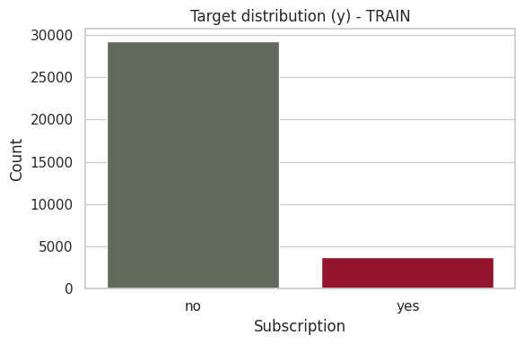

```python
import seaborn as sns
import matplotlib.pyplot as plt

plt.figure(figsize=(6,4))
sns.countplot(data=train_df, x='y', order=["no","yes"], palette=palette_y)
plt.title("Target distribution (y) - TRAIN")
plt.xlabel("Subscription")
plt.ylabel("Count")
plt.tight_layout()
plt.savefig("fig1_y_distribution.png", dpi=300, bbox_inches="tight")
plt.show()
```

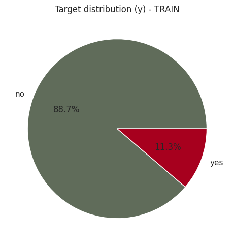

```python
plt.figure(figsize=(5,5))
train_df['y'].value_counts().reindex(["no","yes"]).plot.pie(
    autopct='%1.1f%%',
    colors=[palette_y["no"], palette_y["yes"]]
)
plt.title("Target distribution (y) - TRAIN")
plt.ylabel("")
plt.tight_layout()
plt.savefig("fig2_y_pie.png", dpi=300, bbox_inches="tight")
plt.show()
```

```python
counts = train_df["y"].value_counts().reindex(["no", "yes"])
props = (train_df["y"].value_counts(normalize=True) * 100).reindex(["no", "yes"])

print("Counts (TRAIN):")
print(counts)

print("\nPercentages (TRAIN):")
print(props.round(2))
```

```
Counts (TRAIN):
y
no     29224
yes     3710
Name: count, dtype: int64

Percentages (TRAIN):
y
no    88.74
yes   11.26
Name: proportion, dtype: float64
```

The target variable is clearly imbalanced. The imbalance ratio (no/yes) is 7.88, meaning that there are approximately 7.88 times more “no” outcomes than “yes” outcomes (roughly 8 non-subscribers for every 1 subscriber). This highlights that the positive class (yes) is relatively rare in the dataset

```python
no_count = counts.get('no', 0)
yes_count = counts.get('yes', 0)
print("Imbalance ratio (no/yes):", round(no_count / yes_count, 2))
```

```
Imbalance ratio (no/yes): 7.88
```

To illustrate the implication of this imbalance, we also computed a simple baseline accuracy. If a naïve classifier always predicts the majority class (no) for every customer, it would already achieve an accuracy of 88.74%, simply because most observations belong to the no class. This demonstrates that accuracy alone can be misleading in an imbalanced setting: a model can achieve a high accuracy while failing to identify any yes cases.

```python
baseline_acc = counts.max() / counts.sum()
print("Baseline accuracy (predict majority class):", round(baseline_acc * 100, 2), "%")
```

```
Baseline accuracy (predict majority class): 88.74 %
```

# EDA- Predictive Variable only

```python
import pandas as pd

# Select numeric variables from TRAIN only
num_vars = train_df.select_dtypes(include=["int64", "float64"]).columns.tolist()

# Option: exclude variables you don't want in the numeric summary
num_vars = [c for c in num_vars if c not in ["previously_contacted"]]  # remove this line if you want to keep it

summary = pd.DataFrame({
    "missing": train_df[num_vars].isna().sum(),
    "missing_%": (train_df[num_vars].isna().mean() * 100).round(2),
    "mean": train_df[num_vars].mean(numeric_only=True),
    "std": train_df[num_vars].std(numeric_only=True),
    "min": train_df[num_vars].min(numeric_only=True),
    "25%": train_df[num_vars].quantile(0.25, numeric_only=True),
    "50%": train_df[num_vars].quantile(0.50, numeric_only=True),
    "75%": train_df[num_vars].quantile(0.75, numeric_only=True),
    "max": train_df[num_vars].max(numeric_only=True),
    "skew": train_df[num_vars].skew(numeric_only=True),
    "kurtosis": train_df[num_vars].kurt(numeric_only=True)
}).round(2)

summary.sort_values("missing_%", ascending=False)
```

|  | missing | missing_% | mean | std | min | 25% | 50% | 75% | max | skew | kurtosis |
| --- | --- | --- | --- | --- | --- | --- | --- | --- | --- | --- | --- |
| pdays | 31707 | 96.27 | 6.04 | 3.90 | 0.00 | 3.00 | 6.00 | 7.00 | 27.00 | 1.49 | 2.69 |
| age | 0 | 0.00 | 40.00 | 10.42 | 17.00 | 32.00 | 38.00 | 47.00 | 98.00 | 0.77 | 0.78 |
| duration | 0 | 0.00 | 258.44 | 257.59 | 0.00 | 103.00 | 180.00 | 320.75 | 4199.00 | 3.14 | 17.95 |
| campaign | 0 | 0.00 | 2.56 | 2.78 | 1.00 | 1.00 | 2.00 | 3.00 | 56.00 | 4.88 | 39.19 |
| previous | 0 | 0.00 | 0.17 | 0.49 | 0.00 | 0.00 | 0.00 | 0.00 | 7.00 | 3.82 | 19.97 |
| emp.var.rate | 0 | 0.00 | 0.08 | 1.57 | -3.40 | -1.80 | 1.10 | 1.40 | 1.40 | -0.72 | -1.07 |
| cons.price.idx | 0 | 0.00 | 93.58 | 0.58 | 92.20 | 93.08 | 93.75 | 93.99 | 94.77 | -0.23 | -0.83 |
| cons.conf.idx | 0 | 0.00 | -40.51 | 4.63 | -50.80 | -42.70 | -41.80 | -36.40 | -26.90 | 0.30 | -0.36 |
| euribor3m | 0 | 0.00 | 3.62 | 1.74 | 0.63 | 1.34 | 4.86 | 4.96 | 5.04 | -0.71 | -1.41 |
| nr.employed | 0 | 0.00 | 5166.93 | 72.37 | 4963.60 | 5099.10 | 5191.00 | 5228.10 | 5228.10 | -1.04 | -0.01 |

```python
import numpy as np
import pandas as pd

# Create numeric_df safely (TRAIN only)
numeric_df = train_df.select_dtypes(include=[np.number]).copy()

# Remove binary columns (0/1)
binary_cols = [c for c in numeric_df.columns if train_df[c].nunique(dropna=True) == 2]
numeric_df = numeric_df.drop(columns=binary_cols, errors="ignore")

outliers_detail = []

for col in numeric_df.columns:
    s = numeric_df[col].dropna()
    if s.empty:
        continue

    Q1, Q3 = s.quantile(0.25), s.quantile(0.75)
    IQR = Q3 - Q1
    lb, ub = Q1 - 1.5*IQR, Q3 + 1.5*IQR

    n_out = ((s < lb) | (s > ub)).sum()
    n_tot = s.shape[0]
    outliers_detail.append([col, int(n_out), round(n_out/n_tot*100, 2), lb, ub])

outliers_detail_df = pd.DataFrame(
    outliers_detail,
    columns=["variable", "outliers_count", "outliers_%", "lower_bound", "upper_bound"]
).sort_values("outliers_count", ascending=False)

outliers_detail_df
```

|  | variable | outliers_count | outliers_% | lower_bound | upper_bound |
| --- | --- | --- | --- | --- | --- |
| 4 | previous | 4521 | 13.73 | 0.00 | 0.00 |
| 1 | duration | 2347 | 7.13 | -223.62 | 647.38 |
| 2 | campaign | 1913 | 5.81 | -2.00 | 6.00 |
| 0 | age | 361 | 1.10 | 9.50 | 69.50 |
| 7 | cons.conf.idx | 358 | 1.09 | -52.15 | -26.95 |
| 3 | pdays | 69 | 5.62 | -3.00 | 13.00 |
| 5 | emp.var.rate | 0 | 0.00 | -6.60 | 6.20 |
| 6 | cons.price.idx | 0 | 0.00 | 91.70 | 95.37 |
| 8 | euribor3m | 0 | 0.00 | -4.08 | 10.39 |
| 9 | nr.employed | 0 | 0.00 | 4905.60 | 5421.60 |

```python
import numpy as np
import pandas as pd

# Numeric cols (TRAIN only)
numeric_cols = train_df.select_dtypes(include=[np.number]).copy()

# Remove binary columns (0/1)
binary_cols = [c for c in numeric_cols.columns if train_df[c].nunique(dropna=True) == 2]
numeric_cols = numeric_cols.drop(columns=binary_cols, errors="ignore")

# Compute skewness & kurtosis
skewness = numeric_cols.skew(numeric_only=True).sort_values(ascending=False).round(2)
kurtosis = numeric_cols.kurt(numeric_only=True).sort_values(ascending=False).round(2)

skew_kurt = (pd.DataFrame({
    "skewness": skewness,
    "kurtosis": kurtosis
}).sort_values("skewness", ascending=False))

skew_kurt
```

|  | skewness | kurtosis |
| --- | --- | --- |
| campaign | 4.88 | 39.19 |
| previous | 3.82 | 19.97 |
| duration | 3.14 | 17.95 |
| pdays | 1.49 | 2.69 |
| age | 0.77 | 0.78 |
| cons.conf.idx | 0.30 | -0.36 |
| cons.price.idx | -0.23 | -0.83 |
| euribor3m | -0.71 | -1.41 |
| emp.var.rate | -0.72 | -1.07 |
| nr.employed | -1.04 | -0.01 |

Based on the univariate shape diagnostics (skewness and kurtosis), we assessed whether any numerical predictors would benefit from a logarithmic transformation. Several variables—particularly campaign, previous, and duration—show strong right-skewness and heavy tails, meaning that most observations are small while a small number of extreme values create long upper tails. To improve interpretability during exploratory analysis, a log1p transformation (i.e., log(1 + x)) can be applied to these variables to compress extreme values and make distributions easier to visualise and compare.

```python
# variables tres asymetriques - on visualise en log1p
vars_to_log = ["campaign", "previous", "duration"]
```

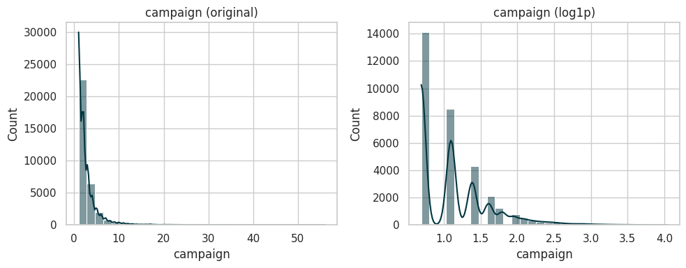

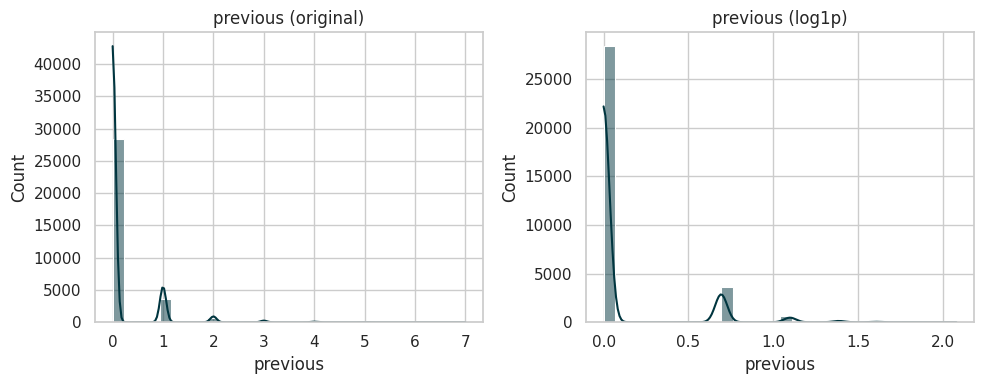

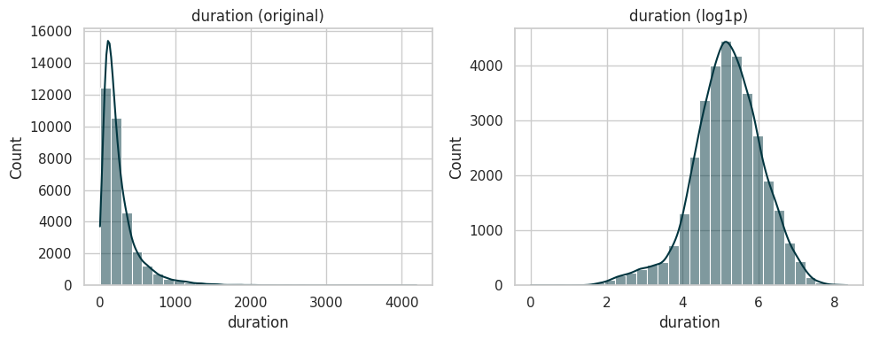

```python
for col in vars_to_log:
    plt.figure(figsize=(10,4))

    plt.subplot(1,2,1)
    sns.histplot(train_df[col].dropna(), bins=30, kde=True, color=main_num_color)
    plt.title(f"{col} (original)")

    plt.subplot(1,2,2)
    sns.histplot(np.log1p(train_df[col].dropna()), bins=30, kde=True, color=main_num_color)
    plt.title(f"{col} (log1p)")

    plt.tight_layout()
    plt.show()
```

After applying the log1p transformation, the distributions look much more balanced and closer to a bell-shaped curve—especially for duration. This shows that the original shape was mainly due to strong right-skewness (a long tail), not because the data was incorrect.

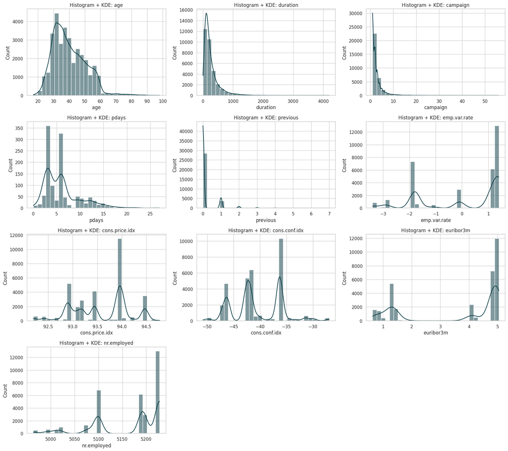

```python
# numeric vars from TRAIN only
num_vars = train_df.select_dtypes(include=["int64", "float64"]).columns.tolist()

# remove binary variable (not suitable for hist + KDE)
num_vars = [c for c in num_vars if c != "previously_contacted"]

ncols = 3
nrows = int(np.ceil(len(num_vars) / ncols))

fig, axes = plt.subplots(nrows, ncols, figsize=(6*ncols, 4*nrows))
axes = np.array(axes).reshape(-1)

for i, col in enumerate(num_vars):
    sns.histplot(train_df[col].dropna(), bins=30, kde=True, ax=axes[i], color=main_num_color)
    axes[i].set_title(f"Histogram + KDE: {col}")
    axes[i].set_xlabel(col)
    axes[i].set_ylabel("Count")

# remove empty axes
for j in range(i+1, len(axes)):
    fig.delaxes(axes[j])

plt.tight_layout()
plt.show()
```

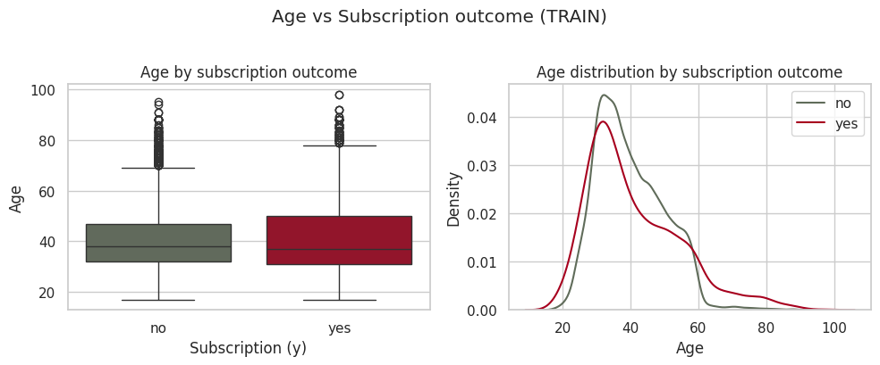

```python
import matplotlib.pyplot as plt
import seaborn as sns

fig, axes = plt.subplots(1, 2, figsize=(10, 4))

# Boxplot
sns.boxplot(data=train_df, x="y", y="age", order=["no", "yes"],
            palette=palette_y, ax=axes[0])
axes[0].set_title("Age by subscription outcome")
axes[0].set_xlabel("Subscription (y)")
axes[0].set_ylabel("Age")

# KDE pour voir la distribution complète
sns.kdeplot(data=train_df[train_df["y"] == "no"], x="age",
            label="no", color="#606C5A", ax=axes[1])
sns.kdeplot(data=train_df[train_df["y"] == "yes"], x="age",
            label="yes", color="#A7001E", ax=axes[1])
axes[1].set_title("Age distribution by subscription outcome")
axes[1].set_xlabel("Age")
axes[1].legend()

plt.suptitle("Age vs Subscription outcome (TRAIN)", y=1.02)
plt.tight_layout()
plt.savefig("fig_age.png", dpi=300, bbox_inches="tight")
plt.show()
```

```python
macro_vars = ['emp.var.rate','cons.price.idx','cons.conf.idx','euribor3m','nr.employed']

(train_df[macro_vars].nunique()
 .sort_values())
```

|  | 0 |
| --- | --- |
| emp.var.rate | 10 |
| nr.employed | 11 |
| cons.conf.idx | 26 |
| cons.price.idx | 26 |
| euribor3m | 310 |

**dtype:** int64

This step checks the number of unique values in each macroeconomic variable. Since most of them take only a few repeated values, they likely reflect time-period economic conditions shared across many customers, not individual customer characteristics.

```python
import numpy as np
from scipy.stats import mannwhitneyu

alpha = 0.05

no  = train_df.loc[train_df["y"] == "no",  "age"].dropna()
yes = train_df.loc[train_df["y"] == "yes", "age"].dropna()

print("Mann–Whitney U test (age by y)")
print("H0: The distribution of age is the same for y='yes' and y='no'.")
print("H1: The distribution of age differs between y='yes' and y='no'.")
print(f"alpha = {alpha}")

u_stat, p_value = mannwhitneyu(yes, no, alternative="two-sided")

print(f"\nU statistic: {u_stat:.2f}")
print(f"p-value: {p_value:.4g}")

if np.isnan(p_value):
    print("\nDecision: p-value is NaN, so the test cannot be interpreted.")
elif p_value < alpha:
    print(f"\nDecision: p-value < {alpha} -> Reject H0.")
    print("Conclusion: Age differs significantly between subscribers and non-subscribers.")
else:
    print(f"\nDecision: p-value >= {alpha} -> Fail to reject H0.")
    print("Conclusion: No significant difference in age was detected between the groups.")

# Effect size — rank-biserial correlation
n1, n2 = len(yes), len(no)
rank_biserial = 1 - (2 * u_stat) / (n1 * n2)
print(f"\nEffect size (rank-biserial correlation): {rank_biserial:.4f}")
print("(|r| < 0.1 = negligible, 0.1–0.3 = small, 0.3–0.5 = medium, > 0.5 = large)")
```

```
Mann–Whitney U test (age by y)
H0: The distribution of age is the same for y='yes' and y='no'.
H1: The distribution of age differs between y='yes' and y='no'.
alpha = 0.05

U statistic: 53403921.50
p-value: 0.139

Decision: p-value >= 0.05 -> Fail to reject H0.
Conclusion: No significant difference in age was detected between the groups.

Effect size (rank-biserial correlation): 0.0149
(|r| < 0.1 = negligible, 0.1–0.3 = small, 0.3–0.5 = medium, > 0.5 = large)
```

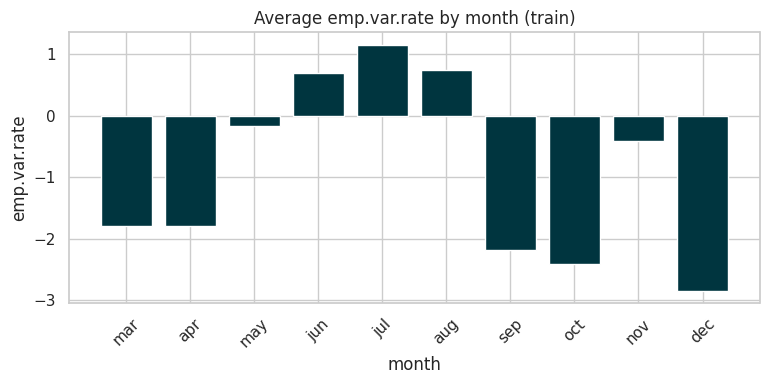

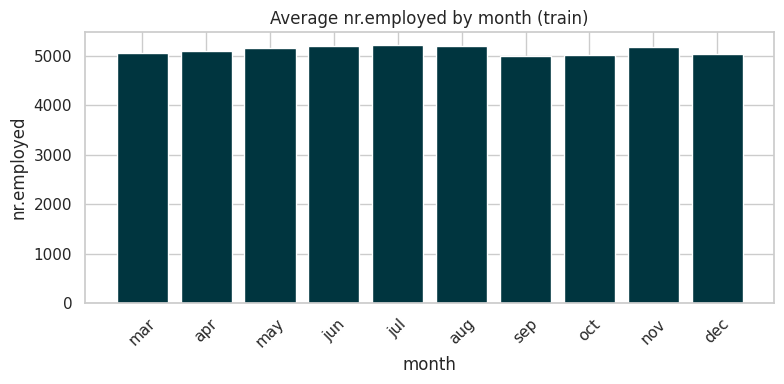

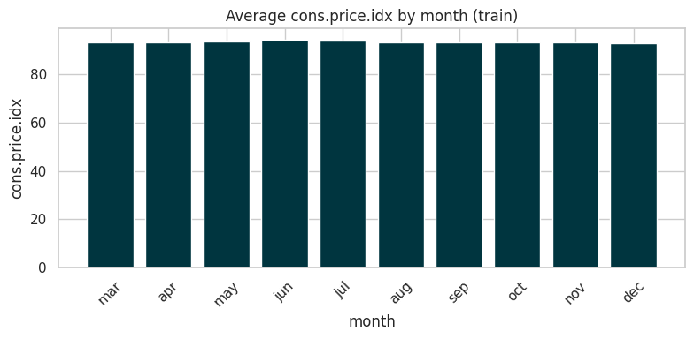

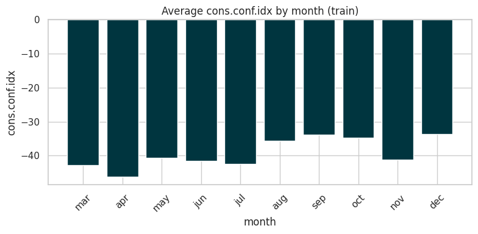

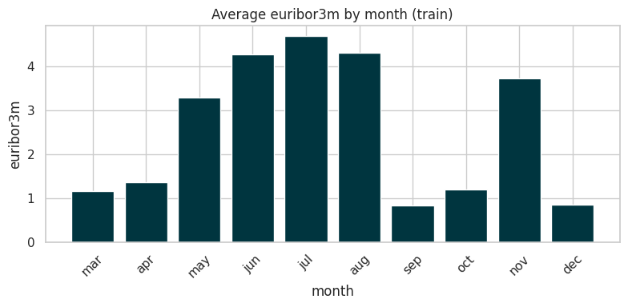

```python
# month en categoriel ordonne (ordre calendaire) sur train + test
month_order = ["jan","feb","mar","apr","may","jun","jul","aug","sep","oct","nov","dec"]
train_df["month"] = pd.Categorical(train_df["month"], categories=month_order, ordered=True)
test_df["month"]  = pd.Categorical(test_df["month"],  categories=month_order, ordered=True)

# moyenne des variables macro par mois
macro_vars = ['emp.var.rate','nr.employed','cons.price.idx','cons.conf.idx','euribor3m']
macro_vars = [v for v in macro_vars if v in train_df.columns]

for v in macro_vars:
    monthly_mean = train_df.groupby("month")[v].mean().sort_index()

    plt.figure(figsize=(8,4))
    plt.bar(monthly_mean.index.astype(str), monthly_mean.values, color=main_num_color)
    plt.title(f"Average {v} by month (train)")
    plt.xlabel("month")
    plt.ylabel(v)
    plt.xticks(rotation=45)
    plt.tight_layout()
    plt.show()
```

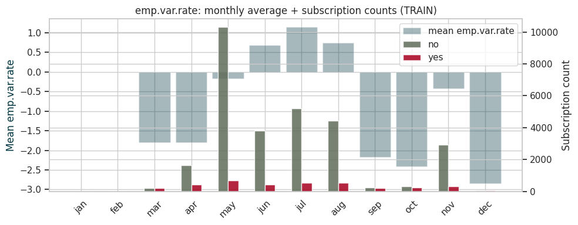

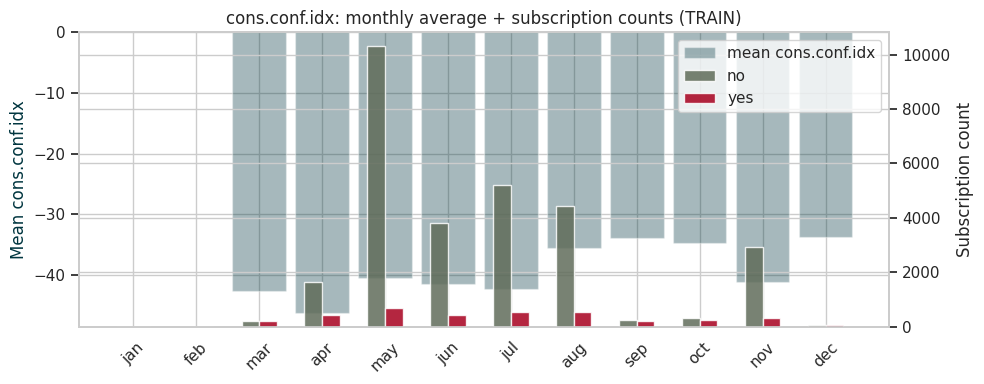

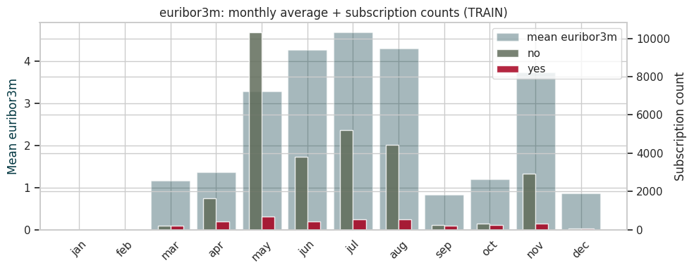

```python
import pandas as pd
import numpy as np
import matplotlib.pyplot as plt
import os

# (optionnel) dossier où tu veux sauvegarder
save_dir = "figures"
os.makedirs(save_dir, exist_ok=True)

month_order = ["jan","feb","mar","apr","may","jun","jul","aug","sep","oct","nov","dec"]
train_df["month"] = pd.Categorical(train_df["month"], categories=month_order, ordered=True)

macro_vars = ["emp.var.rate", "cons.conf.idx", "euribor3m"]

for v in macro_vars:
    monthly_macro = train_df.groupby("month")[v].mean().sort_index()
    month_counts = pd.crosstab(train_df["month"], train_df["y"]).reindex(monthly_macro.index).fillna(0)

    x = np.arange(len(monthly_macro.index))
    fig, ax1 = plt.subplots(figsize=(10,4))

    ax1.bar(x, monthly_macro.values, width=0.85, color=main_num_color, alpha=0.35, label=f"mean {v}")
    ax1.set_ylabel(f"Mean {v}", color=main_num_color)

    ax2 = ax1.twinx()
    w = 0.28
    ax2.bar(x - w/2, month_counts["no"].values, width=w, color=palette_y["no"], alpha=0.85, label="no")
    ax2.bar(x + w/2, month_counts["yes"].values, width=w, color=palette_y["yes"], alpha=0.85, label="yes")
    ax2.set_ylabel("Subscription count")

    ax1.set_xticks(x)
    ax1.set_xticklabels(monthly_macro.index.astype(str), rotation=45)

    plt.title(f"{v}: monthly average + subscription counts (TRAIN)")

    h1, l1 = ax1.get_legend_handles_labels()
    h2, l2 = ax2.get_legend_handles_labels()
    ax2.legend(h1 + h2, l1 + l2, loc="upper right")

    plt.tight_layout()

    # ✅ save with unique filename
    filename = f"macro_overlay_{v.replace('.', '_')}.png"
    filepath = os.path.join(save_dir, filename)
    plt.savefig(filepath, dpi=300, bbox_inches="tight")

    plt.show()
    plt.close(fig)  # évite d'accumuler les figures en mémoire
```

# previously_contacted

```
previously_contacted (TRAIN) - Counts:
previously_contacted
0    31707
1     1227
Name: count, dtype: int64

previously_contacted (TRAIN) - Percentages (%):
previously_contacted
0   96.27
1    3.73
Name: count, dtype: float64
```

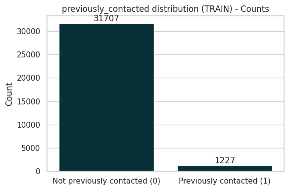

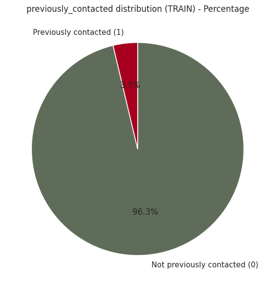

```python
import matplotlib.pyplot as plt
import seaborn as sns

# --- TRAIN only ---
counts_pc = train_df["previously_contacted"].value_counts().sort_index()
perc_pc = (counts_pc / counts_pc.sum() * 100).round(2)

print("previously_contacted (TRAIN) - Counts:")
print(counts_pc)
print("\npreviously_contacted (TRAIN) - Percentages (%):")
print(perc_pc)

labels_map = {0: "Not previously contacted (0)", 1: "Previously contacted (1)"}
x_labels = [labels_map.get(i, str(i)) for i in counts_pc.index]

bar_color = main_num_color
pie_colors = binary_color

# --- 1) Bar chart (counts) ---
fig1, ax1 = plt.subplots(figsize=(6,4))
sns.barplot(x=x_labels, y=counts_pc.values, color=bar_color, ax=ax1)
ax1.set_title("previously_contacted distribution (TRAIN) - Counts")
ax1.set_xlabel("")
ax1.set_ylabel("Count")

for i, v in enumerate(counts_pc.values):
    ax1.text(i, v, str(v), ha="center", va="bottom")

fig1.tight_layout()
fig1.savefig("previously_contacted_counts_train.png", dpi=300, bbox_inches="tight")
plt.show()
plt.close(fig1)

# --- 2) Pie chart (percentages) ---
values = [counts_pc.get(0, 0), counts_pc.get(1, 0)]
pie_labels = [labels_map[0], labels_map[1]]

fig2, ax2 = plt.subplots(figsize=(6,6))
ax2.pie(
    values,
    labels=pie_labels,
    colors=pie_colors,
    autopct="%1.1f%%",
    startangle=90,
    counterclock=False,
    wedgeprops={"edgecolor": "white", "linewidth": 1.2}
)
ax2.set_title("previously_contacted distribution (TRAIN) - Percentage")

fig2.tight_layout()
fig2.savefig("previously_contacted_percent_train.png", dpi=300, bbox_inches="tight")
plt.show()
plt.close(fig2)
```

```python
import pandas as pd
pd.crosstab(train_df['previously_contacted'], train_df['y'], normalize='index') * 100
```

| y previously_contacted | no | yes |
| --- | --- | --- |
| 0 | 90.75 | 9.25 |
| 1 | 36.76 | 63.24 |

```python
import pandas as pd
import numpy as np
from scipy.stats import chi2_contingency

alpha = 0.05

# Contingency table
table = pd.crosstab(train_df["previously_contacted"], train_df["y"])
print("Contingency table (previously_contacted x y):")
print(table)

print("\nHypotheses:")
print("H0: previously_contacted and y are independent (no association).")
print("H1: previously_contacted and y are not independent (association).")
print(f"Significance level: alpha = {alpha}")

# Chi-square test
chi2, p_value, dof, expected = chi2_contingency(table)

print(f"\nChi-square statistic: {chi2:.4f}")
print(f"Degrees of freedom: {dof}")
print(f"p-value: {p_value}")

# Decision
if np.isnan(p_value):
    print("\nDecision: p-value is NaN, so the test result cannot be interpreted.")
    print("This may happen if a category has zero counts or the table is not valid.")
elif p_value < alpha:
    print(f"\nDecision: p-value < {alpha} -> Reject H0.")
    print("Conclusion: There is a statistically significant association between previously_contacted and y.")
else:
    print(f"\nDecision: p-value >= {alpha} -> Fail to reject H0.")
    print("Conclusion: No statistically significant association was found between previously_contacted and y.")

# Optional: Effect size (Cramér's V)
n = table.values.sum()
cramers_v = np.sqrt((chi2 / n) / min(table.shape[0]-1, table.shape[1]-1))
print(f"\nCramér's V (effect size): {cramers_v:.4f}")
```

```
Contingency table (previously_contacted x y):
y                        no   yes
previously_contacted
0                     28773  2934
1                       451   776

Hypotheses:
H0: previously_contacted and y are independent (no association).
H1: previously_contacted and y are not independent (association).
Significance level: alpha = 0.05

Chi-square statistic: 3439.3739
Degrees of freedom: 1
p-value: 0.0

Decision: p-value < 0.05 -> Reject H0.
Conclusion: There is a statistically significant association between previously_contacted and y.

Cramér's V (effect size): 0.3232
```

# NUMERIC VARIABLES

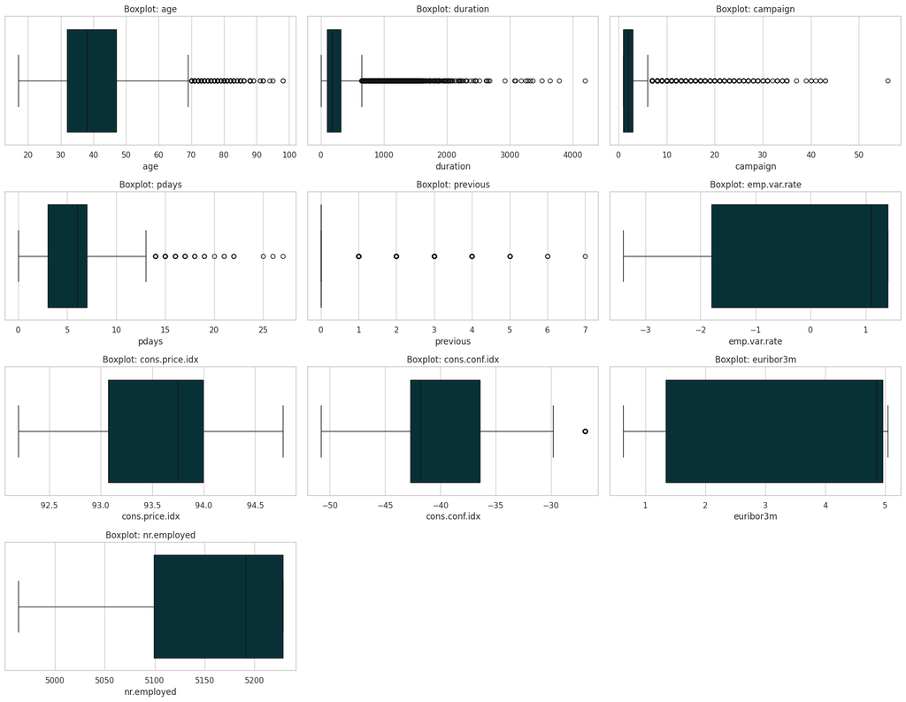

```python
num_vars = train_df.select_dtypes(include=["int64", "float64"]).columns.tolist()
num_vars = [c for c in num_vars if c != "previously_contacted"]  # remove binary var

ncols = 3
nrows = int(np.ceil(len(num_vars) / ncols))

fig, axes = plt.subplots(nrows, ncols, figsize=(6*ncols, 3.5*nrows))
axes = np.array(axes).reshape(-1)

for i, col in enumerate(num_vars):
    sns.boxplot(x=train_df[col].dropna(), ax=axes[i], color=main_num_color)
    axes[i].set_title(f"Boxplot: {col}")
    axes[i].set_xlabel(col)

for j in range(i+1, len(axes)):
    fig.delaxes(axes[j])

plt.tight_layout()
plt.show()
```

[output not shown]

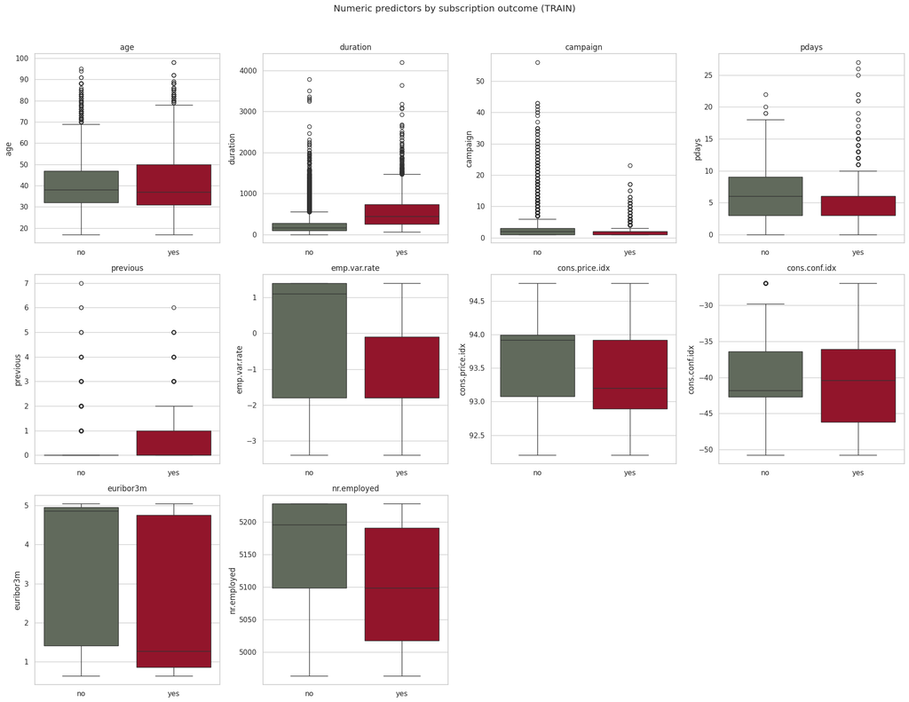

```python
import numpy as np
import seaborn as sns
import matplotlib.pyplot as plt

# Numeric columns from TRAIN
numeric_cols = train_df.select_dtypes(include=np.number).copy()

# Remove binary columns (0/1)
binary_cols = [c for c in numeric_cols.columns if train_df[c].nunique(dropna=True) == 2]
numeric_cols = numeric_cols.drop(columns=binary_cols, errors="ignore")

features = numeric_cols.columns.tolist()

n_cols = 4
n_rows = int(np.ceil(len(features) / n_cols))

fig, axes = plt.subplots(n_rows, n_cols, figsize=(20, 5 * n_rows))
axes = np.array(axes).reshape(-1)

for i, feature in enumerate(features):
    sns.boxplot(
        data=train_df,
        x="y",
        y=feature,
        order=["no", "yes"],       # ✅ guarantees order
        palette=palette_y,
        ax=axes[i]
    )
    axes[i].set_title(feature)
    axes[i].set_xlabel("")
    axes[i].set_ylabel(feature)

# Remove empty subplots
for j in range(i + 1, len(axes)):
    fig.delaxes(axes[j])

fig.suptitle("Numeric predictors by subscription outcome (TRAIN)", y=1.02)
fig.tight_layout()

# Optional: save
# fig.savefig("boxplots_numeric_by_y_train.png", dpi=300, bbox_inches="tight")

plt.show()
plt.close(fig)
```

```python
import numpy as np
import pandas as pd

# 1) Toutes les variables numériques
num_vars = train_df.select_dtypes(include=[np.number]).columns.tolist()

# 2) Enlever les binaires (0/1) si tu veux
binary_vars = [c for c in num_vars if train_df[c].nunique(dropna=True) == 2]
num_vars = [c for c in num_vars if c not in binary_vars]

summary_tidy = []

for f in num_vars:
    desc = train_df.groupby("y")[f].describe(percentiles=[0.25, 0.5, 0.75]).round(2)

    # garder seulement les stats utiles (et éviter le bug des noms)
    cols_to_keep = [c for c in ["count", "mean", "std", "min", "25%", "50%", "75%", "max"] if c in desc.columns]
    desc = desc[cols_to_keep]

    desc["variable"] = f
    summary_tidy.append(desc.reset_index())

summary_tidy_df = pd.concat(summary_tidy, ignore_index=True)
summary_tidy_df
```

|  | y | count | mean | std | min | 25% | 50% | 75% | max | variable |
| --- | --- | --- | --- | --- | --- | --- | --- | --- | --- | --- |
| 0 | no | 29224.00 | 39.88 | 9.89 | 17.00 | 32.00 | 38.00 | 47.00 | 95.00 | age |
| 1 | yes | 3710.00 | 40.99 | 13.87 | 17.00 | 31.00 | 37.00 | 50.00 | 98.00 | age |
| 2 | no | 29224.00 | 221.26 | 205.65 | 0.00 | 95.00 | 164.00 | 280.00 | 3785.00 | duration |
| 3 | yes | 3710.00 | 551.29 | 399.12 | 63.00 | 253.00 | 449.00 | 738.75 | 4199.00 | duration |
| 4 | no | 29224.00 | 2.63 | 2.88 | 1.00 | 1.00 | 2.00 | 3.00 | 56.00 | campaign |
| 5 | yes | 3710.00 | 2.06 | 1.66 | 1.00 | 1.00 | 2.00 | 2.00 | 23.00 | campaign |
| 6 | no | 451.00 | 6.24 | 4.03 | 0.00 | 3.00 | 6.00 | 9.00 | 22.00 | pdays |
| 7 | yes | 776.00 | 5.93 | 3.83 | 0.00 | 3.00 | 6.00 | 6.00 | 27.00 | pdays |
| 8 | no | 29224.00 | 0.13 | 0.41 | 0.00 | 0.00 | 0.00 | 0.00 | 7.00 | previous |
| 9 | yes | 3710.00 | 0.49 | 0.86 | 0.00 | 0.00 | 0.00 | 1.00 | 6.00 | previous |
| 10 | no | 29224.00 | 0.24 | 1.49 | -3.40 | -1.80 | 1.10 | 1.40 | 1.40 | emp.var.rate |
| 11 | yes | 3710.00 | -1.21 | 1.63 | -3.40 | -1.80 | -1.80 | -0.10 | 1.40 | emp.var.rate |
| 12 | no | 29224.00 | 93.60 | 0.56 | 92.20 | 93.08 | 93.92 | 93.99 | 94.77 | cons.price.idx |
| 13 | yes | 3710.00 | 93.36 | 0.68 | 92.20 | 92.89 | 93.20 | 93.92 | 94.77 | cons.price.idx |
| 14 | no | 29224.00 | -40.60 | 4.40 | -50.80 | -42.70 | -41.80 | -36.40 | -26.90 | cons.conf.idx |
| 15 | yes | 3710.00 | -39.81 | 6.11 | -50.80 | -46.20 | -40.40 | -36.10 | -26.90 | cons.conf.idx |
| 16 | no | 29224.00 | 3.81 | 1.64 | 0.63 | 1.40 | 4.86 | 4.96 | 5.04 | euribor3m |
| 17 | yes | 3710.00 | 2.14 | 1.75 | 0.63 | 0.85 | 1.27 | 4.76 | 5.04 | euribor3m |
| 18 | no | 29224.00 | 5175.95 | 64.78 | 4963.60 | 5099.10 | 5195.80 | 5228.10 | 5228.10 | nr.employed |
| 19 | yes | 3710.00 | 5095.86 | 88.05 | 4963.60 | 5017.50 | 5099.10 | 5191.00 | 5228.10 | nr.employed |

# Macro-economic variable

```python
import pandas as pd

features = ["euribor3m", "emp.var.rate", "nr.employed"]
stats = ["count", "mean", "std", "min", "25%", "50%", "75%", "max"]

summary_tidy = []

for f in features:
    desc = train_df.groupby("y")[f].describe(percentiles=[0.25, 0.5, 0.75]).round(2)
    cols_to_keep = [c for c in stats if c in desc.columns]
    desc = desc[cols_to_keep]
    desc["variable"] = f
    summary_tidy.append(desc.reset_index())

macro_summary_df = pd.concat(summary_tidy, ignore_index=True)
macro_summary_df
```

|  | y | count | mean | std | min | 25% | 50% | 75% | max | variable |
| --- | --- | --- | --- | --- | --- | --- | --- | --- | --- | --- |
| 0 | no | 29224.00 | 3.81 | 1.64 | 0.63 | 1.40 | 4.86 | 4.96 | 5.04 | euribor3m |
| 1 | yes | 3710.00 | 2.14 | 1.75 | 0.63 | 0.85 | 1.27 | 4.76 | 5.04 | euribor3m |
| 2 | no | 29224.00 | 0.24 | 1.49 | -3.40 | -1.80 | 1.10 | 1.40 | 1.40 | emp.var.rate |
| 3 | yes | 3710.00 | -1.21 | 1.63 | -3.40 | -1.80 | -1.80 | -0.10 | 1.40 | emp.var.rate |
| 4 | no | 29224.00 | 5175.95 | 64.78 | 4963.60 | 5099.10 | 5195.80 | 5228.10 | 5228.10 | nr.employed |
| 5 | yes | 3710.00 | 5095.86 | 88.05 | 4963.60 | 5017.50 | 5099.10 | 5191.00 | 5228.10 | nr.employed |

```python
import numpy as np
from scipy.stats import mannwhitneyu

alpha = 0.05
macro_vars = ["euribor3m", "emp.var.rate", "nr.employed"]

for var in macro_vars:
    no = train_df.loc[train_df["y"] == "no", var].dropna()
    yes = train_df.loc[train_df["y"] == "yes", var].dropna()

    print(f"\nMann–Whitney U test ({var} by y)")
    print("H0: The distribution is the same for y='yes' and y='no'.")
    print("H1: The distributions differ between y='yes' and y='no'.")
    print(f"alpha = {alpha}")

    u_stat, p_value = mannwhitneyu(yes, no, alternative="two-sided")

    print(f"U statistic: {u_stat:.2f}")
    print(f"p-value: {p_value:.4g}")

    if np.isnan(p_value):
        print("Decision: p-value is NaN (cannot interpret).")
    elif p_value < alpha:
        print(f"Decision: p-value < {alpha} -> Reject H0 (significant difference).")
    else:
        print(f"Decision: p-value >= {alpha} -> Fail to reject H0.")
```

```
Mann–Whitney U test (euribor3m by y)
H0: The distribution is the same for y='yes' and y='no'.
H1: The distributions differ between y='yes' and y='no'.
alpha = 0.05
U statistic: 28199259.00
p-value: 0
Decision: p-value < 0.05 -> Reject H0 (significant difference).

Mann–Whitney U test (emp.var.rate by y)
H0: The distribution is the same for y='yes' and y='no'.
H1: The distributions differ between y='yes' and y='no'.
alpha = 0.05
U statistic: 31150905.00
p-value: 0
Decision: p-value < 0.05 -> Reject H0 (significant difference).

Mann–Whitney U test (nr.employed by y)
H0: The distribution is the same for y='yes' and y='no'.
H1: The distributions differ between y='yes' and y='no'.
alpha = 0.05
U statistic: 27656198.50
p-value: 0
Decision: p-value < 0.05 -> Reject H0 (significant difference).
```

# Timing Variable

```python
import pandas as pd

stats = ["count", "mean", "std", "min", "25%", "50%", "75%", "max"]

# Remove campaign variables from the list
features_no_campaign = [f for f in features if f not in ["campaign", "campaign_log1p"]]

summary_tidy = []
for f in features_no_campaign:
    desc = train_df.groupby("y")[f].describe(percentiles=[0.25, 0.5, 0.75]).round(2)

    # keep only stats that exist (safer across pandas versions)
    cols_to_keep = [c for c in stats if c in desc.columns]
    desc = desc[cols_to_keep]

    desc["variable"] = f
    summary_tidy.append(desc.reset_index())

summary_tidy_df = pd.concat(summary_tidy, ignore_index=True)
summary_tidy_df
```

|  | y | count | mean | std | min | 25% | 50% | 75% | max | variable |
| --- | --- | --- | --- | --- | --- | --- | --- | --- | --- | --- |
| 0 | no | 29224.00 | 3.81 | 1.64 | 0.63 | 1.40 | 4.86 | 4.96 | 5.04 | euribor3m |
| 1 | yes | 3710.00 | 2.14 | 1.75 | 0.63 | 0.85 | 1.27 | 4.76 | 5.04 | euribor3m |
| 2 | no | 29224.00 | 0.24 | 1.49 | -3.40 | -1.80 | 1.10 | 1.40 | 1.40 | emp.var.rate |
| 3 | yes | 3710.00 | -1.21 | 1.63 | -3.40 | -1.80 | -1.80 | -0.10 | 1.40 | emp.var.rate |
| 4 | no | 29224.00 | 5175.95 | 64.78 | 4963.60 | 5099.10 | 5195.80 | 5228.10 | 5228.10 | nr.employed |
| 5 | yes | 3710.00 | 5095.86 | 88.05 | 4963.60 | 5017.50 | 5099.10 | 5191.00 | 5228.10 | nr.employed |

```python
import numpy as np
from scipy.stats import mannwhitneyu

alpha = 0.05

no = train_df.loc[train_df["y"] == "no", "duration"].dropna()
yes = train_df.loc[train_df["y"] == "yes", "duration"].dropna()

print("Mann–Whitney U test (duration by y)")
print("H0: The distribution of duration is the same for y='yes' and y='no'.")
print("H1: The distribution of duration differs between y='yes' and y='no'.")
print(f"alpha = {alpha}")

u_stat, p_value = mannwhitneyu(yes, no, alternative="two-sided")

print(f"\nU statistic: {u_stat:.2f}")
print(f"p-value: {p_value:.4g}")

if np.isnan(p_value):
    print("\nDecision: p-value is NaN, so the test cannot be interpreted.")
elif p_value < alpha:
    print(f"\nDecision: p-value < {alpha} -> Reject H0.")
    print("Conclusion: Duration differs significantly between subscribers and non-subscribers.")
else:
    print(f"\nDecision: p-value >= {alpha} -> Fail to reject H0.")
    print("Conclusion: No significant difference in duration was detected between the groups.")
```

```
Mann–Whitney U test (duration by y)
H0: The distribution of duration is the same for y='yes' and y='no'.
H1: The distribution of duration differs between y='yes' and y='no'.
alpha = 0.05

U statistic: 88613260.50
p-value: 0

Decision: p-value < 0.05 -> Reject H0.
Conclusion: Duration differs significantly between subscribers and non-subscribers.
```

# Categorical Variables

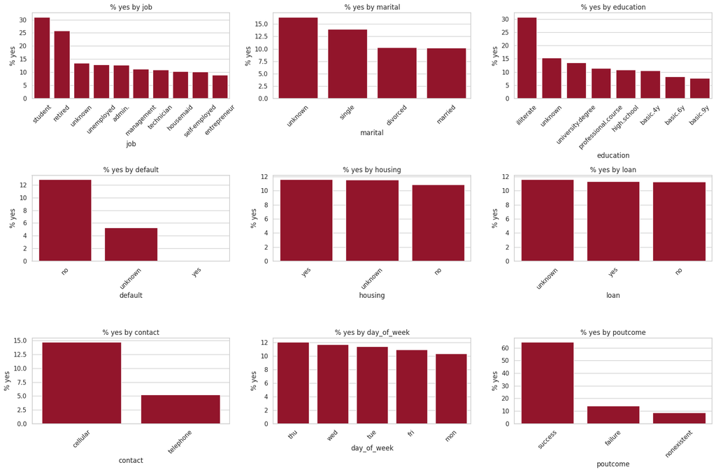

```python
import numpy as np
import seaborn as sns
import matplotlib.pyplot as plt

target = "y"

# categorical variables from TRAIN only
cat_vars = train_df.select_dtypes(include="object").columns.drop(target, errors="ignore").tolist()

# your palette
palette_y = {"no": "#606C5A", "yes": "#A7001E"}
yes_color = palette_y["yes"]

def plot_yes_rate_grid(data, cat_vars, target="y", ncols=3, top_n=10):
    n = len(cat_vars)
    nrows = int(np.ceil(n / ncols))
    fig, axes = plt.subplots(nrows, ncols, figsize=(6*ncols, 4*nrows))
    axes = np.array(axes).reshape(-1)

    for i, col in enumerate(cat_vars):
        tmp = data[[col, target]].dropna()

        rate = (tmp.groupby(col)[target]
                  .apply(lambda s: (s == "yes").mean() * 100)
                  .sort_values(ascending=False))

        if top_n is not None and len(rate) > top_n:
            rate = rate.head(top_n)

        sns.barplot(x=rate.index, y=rate.values, ax=axes[i], color=yes_color)
        axes[i].set_title(f"% yes by {col}")
        axes[i].set_xlabel(col)
        axes[i].set_ylabel("% yes")
        axes[i].tick_params(axis="x", rotation=45)

    # remove empty axes
    for j in range(i+1, len(axes)):
        fig.delaxes(axes[j])

    plt.tight_layout()
    plt.show()

# Use on TRAIN dataset
plot_yes_rate_grid(train_df, cat_vars, target=target, ncols=3, top_n=10)
```

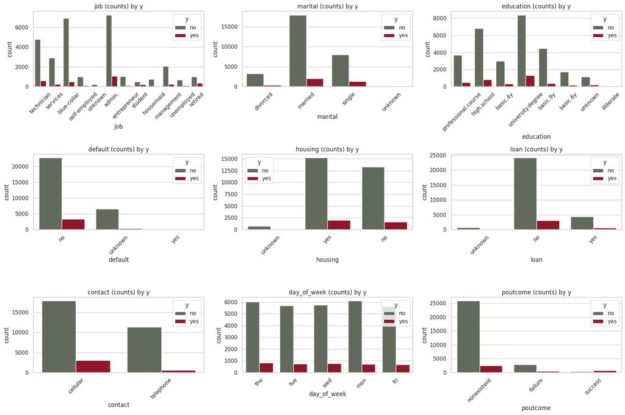

```python
import numpy as np
import seaborn as sns
import matplotlib.pyplot as plt

target = "y"

# categorical variables from TRAIN only
cat_vars = train_df.select_dtypes(include="object").columns.drop(target, errors="ignore").tolist()

ncols = 3
nrows = int(np.ceil(len(cat_vars) / ncols))

fig, axes = plt.subplots(nrows, ncols, figsize=(6*ncols, 4*nrows))
axes = np.array(axes).reshape(-1)

for i, col in enumerate(cat_vars):
    sns.countplot(data=train_df, x=col, hue=target, ax=axes[i], palette=palette_y)
    axes[i].set_title(f"{col} (counts) by {target}")
    axes[i].tick_params(axis="x", rotation=45)

# remove empty axes
for j in range(i+1, len(axes)):
    fig.delaxes(axes[j])

plt.tight_layout()
plt.show()
```

```python
import pandas as pd
import numpy as np

target = "y"
min_n = 50  # minimum observations per category to keep (change if needed)

# Categorical variables (TRAIN only)
cat_vars = train_df.select_dtypes(include="object").columns.drop(target, errors="ignore").tolist()

rows = []

for col in cat_vars:
    tab = pd.crosstab(train_df[col], train_df[target])

    # Ensure both columns exist
    for c in ["no", "yes"]:
        if c not in tab.columns:
            tab[c] = 0

    tab["count_total"] = tab["no"] + tab["yes"]
    tab["yes_rate_%"] = (tab["yes"] / tab["count_total"] * 100).round(2)

    tab = tab.reset_index().rename(columns={col: "category"})
    tab["variable"] = col

    # Filter rare categories
    tab = tab[tab["count_total"] >= min_n]

    rows.append(tab[["variable", "category", "count_total", "yes", "no", "yes_rate_%"]])

cat_summary_df = (pd.concat(rows, ignore_index=True)
                    .sort_values(["variable", "yes_rate_%"], ascending=[True, False]))

cat_summary_df
```

| y | variable | category | count_total | yes | no | yes_rate_% |
| --- | --- | --- | --- | --- | --- | --- |
| 31 | contact | cellular | 20949 | 3081 | 17868 | 14.71 |
| 32 | contact | telephone | 11985 | 629 | 11356 | 5.25 |
| 35 | day_of_week | thu | 6843 | 822 | 6021 | 12.01 |
| 37 | day_of_week | wed | 6523 | 760 | 5763 | 11.65 |
| 36 | day_of_week | tue | 6427 | 733 | 5694 | 11.41 |
| 33 | day_of_week | fri | 6331 | 690 | 5641 | 10.90 |
| 34 | day_of_week | mon | 6810 | 705 | 6105 | 10.35 |
| 23 | default | no | 26038 | 3345 | 22693 | 12.85 |
| 24 | default | unknown | 6893 | 365 | 6528 | 5.30 |
| 22 | education | unknown | 1361 | 209 | 1152 | 15.36 |
| 21 | education | university.degree | 9709 | 1315 | 8394 | 13.54 |
| 20 | education | professional.course | 4166 | 477 | 3689 | 11.45 |
| 19 | education | high.school | 7643 | 828 | 6815 | 10.83 |
| 16 | education | basic.4y | 3333 | 350 | 2983 | 10.50 |
| 17 | education | basic.6y | 1867 | 154 | 1713 | 8.25 |
| 18 | education | basic.9y | 4842 | 373 | 4469 | 7.70 |
| 27 | housing | yes | 17197 | 1992 | 15205 | 11.58 |
| 26 | housing | unknown | 804 | 93 | 711 | 11.57 |
| 25 | housing | no | 14933 | 1625 | 13308 | 10.88 |
| 8 | job | student | 718 | 223 | 495 | 31.06 |
| 5 | job | retired | 1350 | 349 | 1001 | 25.85 |
| 11 | job | unknown | 258 | 35 | 223 | 13.57 |
| 10 | job | unemployed | 798 | 103 | 695 | 12.91 |
| 0 | job | admin. | 8324 | 1062 | 7262 | 12.76 |
| 4 | job | management | 2341 | 265 | 2076 | 11.32 |
| 9 | job | technician | 5398 | 590 | 4808 | 10.93 |
| 3 | job | housemaid | 845 | 87 | 758 | 10.30 |
| 6 | job | self-employed | 1122 | 115 | 1007 | 10.25 |
| 2 | job | entrepreneur | 1146 | 103 | 1043 | 8.99 |
| 7 | job | services | 3191 | 262 | 2929 | 8.21 |
| 1 | job | blue-collar | 7443 | 516 | 6927 | 6.93 |
| 29 | loan | unknown | 804 | 93 | 711 | 11.57 |
| 30 | loan | yes | 4948 | 560 | 4388 | 11.32 |
| 28 | loan | no | 27182 | 3057 | 24125 | 11.25 |
| 15 | marital | unknown | 67 | 11 | 56 | 16.42 |
| 14 | marital | single | 9257 | 1293 | 7964 | 13.97 |
| 12 | marital | divorced | 3665 | 376 | 3289 | 10.26 |
| 13 | marital | married | 19945 | 2030 | 17915 | 10.18 |
| 40 | poutcome | success | 1110 | 716 | 394 | 64.50 |
| 38 | poutcome | failure | 3411 | 479 | 2932 | 14.04 |
| 39 | poutcome | nonexistent | 28413 | 2515 | 25898 | 8.85 |

# Correlation Matrix

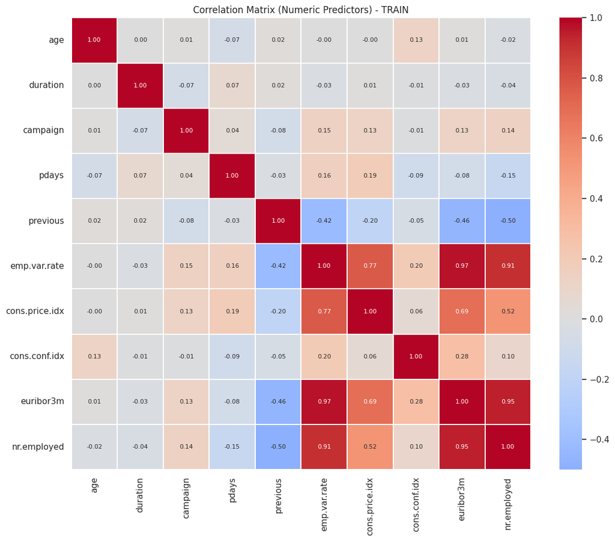

```python
import numpy as np
import seaborn as sns
import matplotlib.pyplot as plt

# Numeric features from TRAIN only
numeric_df = train_df.select_dtypes(include=[np.number]).copy()

# Remove binary variable(s)
binary_cols = [c for c in numeric_df.columns if train_df[c].nunique(dropna=True) == 2]
numeric_df = numeric_df.drop(columns=binary_cols, errors="ignore")

corr_matrix = numeric_df.corr().round(2)

fig, ax = plt.subplots(figsize=(12, 10))
sns.heatmap(
    corr_matrix,
    cmap="coolwarm",
    center=0,
    linewidths=0.3,
    annot=True,
    fmt=".2f",
    annot_kws={"size": 8},
    ax=ax
)

ax.set_title("Correlation Matrix (Numeric Predictors) - TRAIN")
fig.tight_layout()

fig.savefig("correlation_matrix_train.png", dpi=300, bbox_inches="tight")
plt.show()
plt.close(fig)
```

```python
threshold = 0.8

high_corr = (
    corr_matrix.abs()
    .where(np.triu(np.ones(corr_matrix.shape), k=1).astype(bool))
    .stack()
    .sort_values(ascending=False)
)

print("Highly correlated pairs (|corr| > 0.8):")
high_corr[high_corr > threshold]
```

```
Highly correlated pairs (|corr| > 0.8):
```

|  |  | 0 |
| --- | --- | --- |
| emp.var.rate | euribor3m | 0.97 |
| euribor3m | nr.employed | 0.95 |
| emp.var.rate | nr.employed | 0.91 |

**dtype:** float64

```python
# Quick sanity checks for accidental use of df after split
print("train_df exists:", "train_df" in globals())
print("test_df exists:", "test_df" in globals())
print("df exists:", "df" in globals())

# If you see target plots / EDA using df after the split, replace df -> train_df.
```

```
train_df exists: True
test_df exists: True
df exists: True
```

```python
import glob, zipfile

png_files = glob.glob("*.png")  # toutes les images dans le dossier courant
zip_name = "eda_figures.zip"

with zipfile.ZipFile(zip_name, "w", compression=zipfile.ZIP_DEFLATED) as z:
    for f in png_files:
        z.write(f)

print(f"Zipped {len(png_files)} files into {zip_name}")
```

```
Zipped 6 files into eda_figures.zip
```

```python
from google.colab import files
files.download("eda_figures.zip")
```

# ASSIGNMENT 3

```python
# imports modelling
from sklearn.linear_model import LogisticRegression
from sklearn.ensemble import RandomForestClassifier, HistGradientBoostingClassifier
from sklearn.preprocessing import StandardScaler, OneHotEncoder
from sklearn.compose import ColumnTransformer
from sklearn.pipeline import Pipeline
from sklearn.model_selection import StratifiedKFold, cross_validate
from sklearn.metrics import (roc_auc_score, average_precision_score,
                             f1_score, recall_score, precision_score,
                             roc_curve, precision_recall_curve,
                             classification_report, confusion_matrix)

# y en 0/1
y_train = (train_df['y'] == 'yes').astype(int)
y_test  = (test_df['y']  == 'yes').astype(int)

print('train:', train_df.shape, 'pos:', y_train.sum(), f'({y_train.mean()*100:.2f}%)')
print('test :', test_df.shape,  'pos:', y_test.sum(),  f'({y_test.mean()*100:.2f}%)')
```

```
train: (32934, 22) pos: 3710 (11.26%)
test : (8234, 22) pos: 927 (11.26%)
```

```python
# variables apres l'EDA :
# - euribor3m seul pour le bloc macro (correlations >0.9 avec emp.var.rate et nr.employed)
# - pdays retire (trop de NaN, info dans previously_contacted)

cat_cols = ['job', 'marital', 'education', 'default', 'housing', 'loan',
            'contact', 'month', 'day_of_week', 'poutcome']

num_cols_pre = ['age', 'campaign', 'previous',
                'euribor3m', 'cons.price.idx', 'cons.conf.idx']

bin_cols = ['previously_contacted']   # binaire 0/1, pas besoin de scaler

# Config A : pre-contact (variables connues avant l'appel)
feats_A = cat_cols + num_cols_pre + bin_cols
# Config B : avec duration (donnee post-appel)
feats_B = feats_A + ['duration']

print('Config A:', len(feats_A), 'features')
print('Config B:', len(feats_B), 'features')
```

```
Config A: 17 features
Config B: 18 features
```

## Multicollinearity check (VIF)

Before fitting the Logistic Regression, on verifie qu'il n'y a pas de multicolinearite forte entre les predicteurs numeriques. C'est une hypothese cle de la regression logistique : si deux variables sont quasi identiques, leurs coefficients deviennent instables et difficiles a interpreter.

```python
# Variance Inflation Factor pour les numeriques pre-contact
# regle empirique : VIF > 10 = multicollinearite problematique

from statsmodels.stats.outliers_influence import variance_inflation_factor
from sklearn.preprocessing import StandardScaler

# on standardise pour avoir des VIF interpretables
X_num = train_df[num_cols_pre].copy()
X_num_scaled = pd.DataFrame(StandardScaler().fit_transform(X_num), columns=num_cols_pre)

vif_data = pd.DataFrame({
    'feature': X_num_scaled.columns,
    'VIF': [variance_inflation_factor(X_num_scaled.values, i) for i in range(X_num_scaled.shape[1])]
})
print('VIF apres avoir retire emp.var.rate et nr.employed (deja exclus en amont) :')
vif_data.sort_values('VIF', ascending=False).round(2)
```

```
VIF apres avoir retire emp.var.rate et nr.employed (deja exclus en amont) :
```

|  | feature | VIF |
| --- | --- | --- |
| 3 | euribor3m | 2.69 |
| 4 | cons.price.idx | 2.04 |
| 2 | previous | 1.32 |
| 5 | cons.conf.idx | 1.16 |
| 1 | campaign | 1.02 |
| 0 | age | 1.02 |

```python
# preprocessing : scaler num, passthrough binaire, one-hot cat
# (sparse_output=False car HistGradientBoosting attend du dense)
# on clone() les prep pour chaque pipeline (sinon ils partagent le meme objet en memoire)

from sklearn.base import clone

prep_A = ColumnTransformer([
    ('num', StandardScaler(), num_cols_pre),
    ('bin', 'passthrough', bin_cols),
    ('cat', OneHotEncoder(handle_unknown='ignore', drop='first', sparse_output=False), cat_cols)
])

prep_B = ColumnTransformer([
    ('num', StandardScaler(), num_cols_pre + ['duration']),
    ('bin', 'passthrough', bin_cols),
    ('cat', OneHotEncoder(handle_unknown='ignore', drop='first', sparse_output=False), cat_cols)
])

# LogReg (parametrique)
logreg_A = Pipeline([('prep', clone(prep_A)),
                     ('clf', LogisticRegression(max_iter=2000, class_weight='balanced', random_state=42))])
logreg_B = Pipeline([('prep', clone(prep_B)),
                     ('clf', LogisticRegression(max_iter=2000, class_weight='balanced', random_state=42))])

# Random Forest (non-parametrique)
rf_A = Pipeline([('prep', clone(prep_A)),
                 ('clf', RandomForestClassifier(n_estimators=300, max_depth=12,
                                                class_weight='balanced', random_state=42, n_jobs=-1))])
rf_B = Pipeline([('prep', clone(prep_B)),
                 ('clf', RandomForestClassifier(n_estimators=300, max_depth=12,
                                                class_weight='balanced', random_state=42, n_jobs=-1))])

# Gradient Boosting (non-parametrique)
# pas de class_weight ici : pas supporte dans toutes les versions de sklearn
gb_A = Pipeline([('prep', clone(prep_A)),
                 ('clf', HistGradientBoostingClassifier(max_iter=300, max_depth=8,
                                                        learning_rate=0.05,
                                                        random_state=42))])
gb_B = Pipeline([('prep', clone(prep_B)),
                 ('clf', HistGradientBoostingClassifier(max_iter=300, max_depth=8,
                                                        learning_rate=0.05,
                                                        random_state=42))])

models = {
    'LogReg_PreContact': (logreg_A, feats_A),
    'LogReg_Full':       (logreg_B, feats_B),
    'RF_PreContact':     (rf_A, feats_A),
    'RF_Full':           (rf_B, feats_B),
    'GB_PreContact':     (gb_A, feats_A),
    'GB_Full':           (gb_B, feats_B),
}
```

## Hyperparameter tuning (GridSearchCV)

Jusque la les hyperparametres etaient choisis manuellement (valeurs raisonnables mais pas optimisees). On fait maintenant une recherche par grille avec CV stratifiee pour chaque modele, en optimisant la PR-AUC (metrique appropriee vu le desequilibre). On tune uniquement sur la config pre-contact (la seule realiste pour le deploiement).

```python
# GridSearchCV sur les 3 modeles pre-contact
# version allegee pour eviter les problemes de memoire sur Colab gratuit

from sklearn.model_selection import GridSearchCV

cv = StratifiedKFold(n_splits=5, shuffle=True, random_state=42)

# --- LogReg : on tune C (force de la regularisation Ridge) ---
lr_params = {'clf__C': [0.01, 0.1, 1.0, 10.0]}
lr_grid = GridSearchCV(logreg_A, lr_params, cv=cv, scoring='average_precision', n_jobs=2)
lr_grid.fit(train_df[feats_A], y_train)
print('LogReg best params :', lr_grid.best_params_)
print(f'LogReg best CV PR-AUC : {lr_grid.best_score_:.4f}')
print()

# --- Random Forest : grille reduite + n_jobs limite pour eviter les crashs memoire ---
rf_params = {
    'clf__n_estimators':     [200, 300],          # reduit (avant 200/300/500)
    'clf__max_depth':        [8, 12, 16],         # reduit (avant 8/12/16/None)
    'clf__min_samples_split':[2, 10],             # reduit (avant 2/5/10)
}
rf_grid = GridSearchCV(rf_A, rf_params, cv=cv, scoring='average_precision', n_jobs=2)
rf_grid.fit(train_df[feats_A], y_train)
print('RF best params :', rf_grid.best_params_)
print(f'RF best CV PR-AUC : {rf_grid.best_score_:.4f}')
print()

# --- Gradient Boosting : grille reduite ---
gb_params = {
    'clf__max_iter':      [200, 300],             # reduit
    'clf__max_depth':     [5, 8],                 # reduit
    'clf__learning_rate': [0.05, 0.1],            # reduit
}
gb_grid = GridSearchCV(gb_A, gb_params, cv=cv, scoring='average_precision', n_jobs=2)
gb_grid.fit(train_df[feats_A], y_train)
print('GBM best params :', gb_grid.best_params_)
print(f'GBM best CV PR-AUC : {gb_grid.best_score_:.4f}')
```

```
LogReg best params : {'clf__C': 0.01}
LogReg best CV PR-AUC : 0.4348

RF best params : {'clf__max_depth': 12, 'clf__min_samples_split': 10, 'clf__n_estimators': 200}
RF best CV PR-AUC : 0.4556

GBM best params : {'clf__learning_rate': 0.05, 'clf__max_depth': 8, 'clf__max_iter': 200}
GBM best CV PR-AUC : 0.4655
```

### Application des meilleurs hyperparametres

On remplace les pipelines pre-contact par les versions tunees, et on garde les Full inchanges (ils servent uniquement de benchmark, pas besoin de les tuner).

```python
# on recupere les meilleurs estimateurs et on les remet dans le dict 'models'
# (les Full restent inchanges, ils servent juste de benchmark)

logreg_A_tuned = lr_grid.best_estimator_
rf_A_tuned     = rf_grid.best_estimator_
gb_A_tuned     = gb_grid.best_estimator_

models['LogReg_PreContact'] = (logreg_A_tuned, feats_A)
models['RF_PreContact']     = (rf_A_tuned,     feats_A)
models['GB_PreContact']     = (gb_A_tuned,     feats_A)

print('Pipelines pre-contact mis a jour avec les hyperparametres tunes.')
print('A relancer ensuite : cellules CV (74) et test set (75) pour avoir les nouveaux scores.')
```

```
Pipelines pre-contact mis a jour avec les hyperparametres tunes.
A relancer ensuite : cellules CV (74) et test set (75) pour avoir les nouveaux scores.
```

```python
# CV stratifiee 5 folds
# PR-AUC comme metrique principale (classes desequilibrees ~1:8)

cv = StratifiedKFold(n_splits=5, shuffle=True, random_state=42)
scoring = ['roc_auc', 'average_precision', 'f1', 'recall', 'precision']

cv_rows = []
for name, (pipe, feats) in models.items():
    print(name, '...')
    sc = cross_validate(pipe, train_df[feats], y_train, cv=cv, scoring=scoring, n_jobs=-1)
    cv_rows.append({
        'Model': name,
        'ROC_AUC': sc['test_roc_auc'].mean(),
        'PR_AUC': sc['test_average_precision'].mean(),
        'F1': sc['test_f1'].mean(),
        'Recall': sc['test_recall'].mean(),
        'Precision': sc['test_precision'].mean(),
    })

cv_res = pd.DataFrame(cv_rows).set_index('Model').round(4)
cv_res
```

```
LogReg_PreContact ...
LogReg_Full ...
RF_PreContact ...
RF_Full ...
GB_PreContact ...
GB_Full ...
```

| Model | ROC_AUC | PR_AUC | F1 | Recall | Precision |
| --- | --- | --- | --- | --- | --- |
| LogReg_PreContact | 0.79 | 0.43 | 0.43 | 0.63 | 0.33 |
| LogReg_Full | 0.93 | 0.58 | 0.59 | 0.88 | 0.44 |
| RF_PreContact | 0.80 | 0.46 | 0.48 | 0.59 | 0.41 |
| RF_Full | 0.94 | 0.63 | 0.61 | 0.87 | 0.47 |
| GB_PreContact | 0.80 | 0.47 | 0.36 | 0.25 | 0.65 |
| GB_Full | 0.95 | 0.66 | 0.59 | 0.53 | 0.65 |

```python
# fit sur train + eval sur test

fitted = {}
test_rows = []

for name, (pipe, feats) in models.items():
    pipe.fit(train_df[feats], y_train)
    fitted[name] = pipe

    proba = pipe.predict_proba(test_df[feats])[:, 1]
    pred  = pipe.predict(test_df[feats])

    test_rows.append({
        'Model': name,
        'ROC_AUC': roc_auc_score(y_test, proba),
        'PR_AUC': average_precision_score(y_test, proba),
        'F1': f1_score(y_test, pred),
        'Recall': recall_score(y_test, pred),
        'Precision': precision_score(y_test, pred),
    })

test_res = pd.DataFrame(test_rows).set_index('Model').round(4)
test_res
```

| Model | ROC_AUC | PR_AUC | F1 | Recall | Precision |
| --- | --- | --- | --- | --- | --- |
| LogReg_PreContact | 0.80 | 0.46 | 0.45 | 0.66 | 0.34 |
| LogReg_Full | 0.94 | 0.61 | 0.60 | 0.90 | 0.45 |
| RF_PreContact | 0.81 | 0.50 | 0.52 | 0.64 | 0.44 |
| RF_Full | 0.95 | 0.69 | 0.63 | 0.91 | 0.48 |
| GB_PreContact | 0.82 | 0.49 | 0.36 | 0.25 | 0.69 |
| GB_Full | 0.95 | 0.68 | 0.61 | 0.56 | 0.67 |

## Dummy baselines

Pour mettre la performance des modeles en perspective face au desequilibre des classes, on entraine deux baselines triviales :

- **most_frequent** : predit toujours la classe majoritaire (no)
- **stratified** : predit proportionnellement aux frequences observees

Si nos vrais modeles ne battent pas ces baselines clairement, c'est qu'ils n'apprennent rien d'utile.

```python
# dummy baselines pour mettre en perspective le desequilibre
from sklearn.dummy import DummyClassifier

dummies = {
    'Dummy_MostFrequent': DummyClassifier(strategy='most_frequent', random_state=42),
    'Dummy_Stratified': DummyClassifier(strategy='stratified', random_state=42),
}

dummy_rows = []
for name, dum in dummies.items():
    dum.fit(train_df[feats_A], y_train)
    pred  = dum.predict(test_df[feats_A])
    proba = dum.predict_proba(test_df[feats_A])[:, 1]
    dummy_rows.append({
        'Model': name,
        'Accuracy':  (pred == y_test).mean(),
        'ROC_AUC':   roc_auc_score(y_test, proba),
        'PR_AUC':    average_precision_score(y_test, proba),
        'F1':        f1_score(y_test, pred, zero_division=0),
        'Recall':    recall_score(y_test, pred, zero_division=0),
        'Precision': precision_score(y_test, pred, zero_division=0),
    })

dummy_res = pd.DataFrame(dummy_rows).set_index('Model').round(4)
print('Dummy baselines (TEST set) :')
dummy_res
```

```
Dummy baselines (TEST set) :
```

| Model | Accuracy | ROC_AUC | PR_AUC | F1 | Recall | Precision |
| --- | --- | --- | --- | --- | --- | --- |
| Dummy_MostFrequent | 0.89 | 0.50 | 0.11 | 0.00 | 0.00 | 0.00 |
| Dummy_Stratified | 0.80 | 0.50 | 0.11 | 0.12 | 0.12 | 0.12 |

```python
# threshold tuning sur les modeles pre-contact
# le seuil 0.5 par defaut n'est pas optimal avec class_weight='balanced'
# on regarde l'effet de differents seuils sur precision / recall / F1

thresholds = [0.10, 0.20, 0.30, 0.40, 0.50]

for name in ['LogReg_PreContact', 'RF_PreContact', 'GB_PreContact']:
    feats = models[name][1]
    y_proba = fitted[name].predict_proba(test_df[feats])[:, 1]

    print(f"\n{name} - threshold tuning (TEST):")
    for t in thresholds:
        y_pred_t = (y_proba >= t).astype(int)
        prec = precision_score(y_test, y_pred_t, zero_division=0)
        rec  = recall_score(y_test, y_pred_t, zero_division=0)
        f1   = f1_score(y_test, y_pred_t, zero_division=0)
        print(f"t={t:.2f} | precision={prec:.3f} | recall={rec:.3f} | f1={f1:.3f}")
```

```
LogReg_PreContact - threshold tuning (TEST):
t=0.10 | precision=0.113 | recall=1.000 | f1=0.203
t=0.20 | precision=0.122 | recall=0.964 | f1=0.217
t=0.30 | precision=0.153 | recall=0.879 | f1=0.261
t=0.40 | precision=0.257 | recall=0.739 | f1=0.381
t=0.50 | precision=0.345 | recall=0.659 | f1=0.453

RF_PreContact - threshold tuning (TEST):
t=0.10 | precision=0.113 | recall=1.000 | f1=0.202
t=0.20 | precision=0.129 | recall=0.955 | f1=0.227
t=0.30 | precision=0.186 | recall=0.848 | f1=0.305
t=0.40 | precision=0.330 | recall=0.696 | f1=0.448
t=0.50 | precision=0.438 | recall=0.635 | f1=0.519

GB_PreContact - threshold tuning (TEST):
t=0.10 | precision=0.359 | recall=0.680 | f1=0.470
t=0.20 | precision=0.482 | recall=0.608 | f1=0.538
t=0.30 | precision=0.516 | recall=0.499 | f1=0.508
t=0.40 | precision=0.613 | recall=0.318 | f1=0.419
t=0.50 | precision=0.690 | recall=0.247 | f1=0.364
```

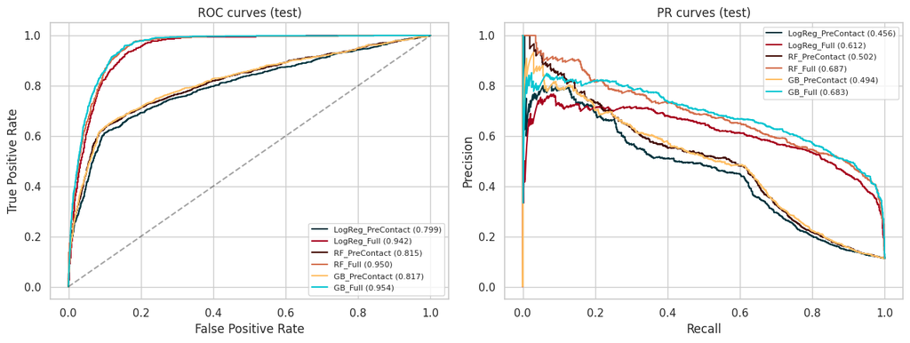

```python
# courbes ROC et PR sur le test

fig, axes = plt.subplots(1, 2, figsize=(13, 5))

model_colors = {
    'LogReg_PreContact': colors[4],
    'LogReg_Full':       colors[5],
    'RF_PreContact':     colors[0],
    'RF_Full':           colors[1],
    'GB_PreContact':     colors[2],
    'GB_Full':           colors[3],
}

for name, pipe in fitted.items():
    feats = models[name][1]
    proba = pipe.predict_proba(test_df[feats])[:, 1]

    fpr, tpr, _ = roc_curve(y_test, proba)
    axes[0].plot(fpr, tpr, label=f'{name} ({roc_auc_score(y_test, proba):.3f})',
                 color=model_colors[name])

    prec, rec, _ = precision_recall_curve(y_test, proba)
    axes[1].plot(rec, prec, label=f'{name} ({average_precision_score(y_test, proba):.3f})',
                 color=model_colors[name])

axes[0].plot([0, 1], [0, 1], 'k--', alpha=0.4)
axes[0].set_xlabel('False Positive Rate')
axes[0].set_ylabel('True Positive Rate')
axes[0].set_title('ROC curves (test)')
axes[0].legend(fontsize=8)

axes[1].set_xlabel('Recall')
axes[1].set_ylabel('Precision')
axes[1].set_title('PR curves (test)')
axes[1].legend(fontsize=8)

plt.tight_layout()
plt.savefig('at3_roc_pr.png', dpi=150, bbox_inches='tight')
plt.show()
```

```python
# coefs LogReg (modele pre-contact)
# odds ratio > 1 = augmente la proba de souscrire

lr = fitted['LogReg_PreContact']
ohe = lr.named_steps['prep'].named_transformers_['cat']
cat_names = list(ohe.get_feature_names_out(cat_cols))
feat_names = num_cols_pre + bin_cols + cat_names

coefs = lr.named_steps['clf'].coef_[0]
coef_df = pd.DataFrame({'feature': feat_names,
                        'coef': coefs,
                        'odds_ratio': np.exp(coefs)})
coef_df = coef_df.reindex(coef_df['coef'].abs().sort_values(ascending=False).index)

print('Top 15 coefs - LogReg pre-contact')
coef_df.head(15).round(3)
```

```
Top 15 coefs - LogReg pre-contact
```

|  | feature | coef | odds_ratio |
| --- | --- | --- | --- |
| 3 | euribor3m | -0.90 | 0.41 |
| 6 | previously_contacted | 0.78 | 2.17 |
| 40 | month_may | -0.67 | 0.51 |
| 49 | poutcome_success | 0.67 | 1.95 |
| 39 | month_mar | 0.64 | 1.89 |
| 34 | contact_telephone | -0.36 | 0.70 |
| 42 | month_oct | 0.35 | 1.42 |
| 48 | poutcome_nonexistent | 0.29 | 1.34 |
| 11 | job_retired | 0.27 | 1.31 |
| 4 | cons.price.idx | 0.24 | 1.27 |
| 5 | cons.conf.idx | 0.21 | 1.24 |
| 28 | default_unknown | -0.21 | 0.81 |
| 14 | job_student | 0.18 | 1.20 |
| 37 | month_jul | 0.15 | 1.17 |
| 19 | marital_single | 0.14 | 1.15 |

```python
# importance des features - RF pre-contact

rf = fitted['RF_PreContact']
imp = rf.named_steps['clf'].feature_importances_
imp_df = pd.DataFrame({'feature': feat_names, 'importance': imp})
imp_df = imp_df.sort_values('importance', ascending=False)

imp_df.head(15).round(4)
```

|  | feature | importance |
| --- | --- | --- |
| 3 | euribor3m | 0.26 |
| 5 | cons.conf.idx | 0.11 |
| 4 | cons.price.idx | 0.10 |
| 6 | previously_contacted | 0.07 |
| 49 | poutcome_success | 0.06 |
| 0 | age | 0.05 |
| 34 | contact_telephone | 0.04 |
| 40 | month_may | 0.03 |
| 2 | previous | 0.03 |
| 1 | campaign | 0.03 |
| 48 | poutcome_nonexistent | 0.02 |
| 42 | month_oct | 0.02 |
| 28 | default_unknown | 0.02 |
| 39 | month_mar | 0.01 |
| 7 | job_blue-collar | 0.01 |

```python
# importance GBM via permutation importance (sur le test)
from sklearn.inspection import permutation_importance

gb = fitted['GB_PreContact']
perm = permutation_importance(gb, test_df[feats_A], y_test,
                              n_repeats=5, random_state=42, n_jobs=-1,
                              scoring='average_precision')

# permutation_importance donne les importances sur les features ORIGINALES (pas one-hot)
gb_imp = pd.DataFrame({'feature': feats_A,
                       'importance': perm.importances_mean}).sort_values('importance', ascending=False)

print('Top 10 features - GBM pre-contact')
gb_imp.head(10).round(4)
```

```
Top 10 features - GBM pre-contact
```

|  | feature | importance |
| --- | --- | --- |
| 13 | euribor3m | 0.25 |
| 14 | cons.price.idx | 0.08 |
| 16 | previously_contacted | 0.04 |
| 7 | month | 0.03 |
| 6 | contact | 0.02 |
| 8 | day_of_week | 0.01 |
| 11 | campaign | 0.01 |
| 9 | poutcome | 0.01 |
| 15 | cons.conf.idx | 0.01 |
| 12 | previous | 0.00 |

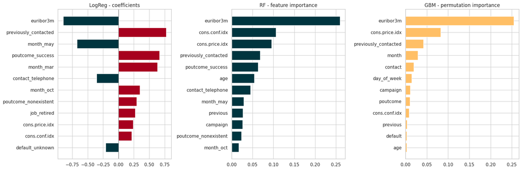

```python
# comparaison visuelle des 3 modeles

fig, axes = plt.subplots(1, 3, figsize=(18, 6))

top_c = coef_df.head(12).iloc[::-1]
bar_colors = [colors[5] if c > 0 else colors[4] for c in top_c['coef']]
axes[0].barh(top_c['feature'], top_c['coef'], color=bar_colors)
axes[0].axvline(0, color='k', linewidth=0.5)
axes[0].set_title('LogReg - coefficients')

top_i = imp_df.head(12).iloc[::-1]
axes[1].barh(top_i['feature'], top_i['importance'], color=colors[4])
axes[1].set_title('RF - feature importance')

top_g = gb_imp.head(12).iloc[::-1]
axes[2].barh(top_g['feature'], top_g['importance'], color=colors[2])
axes[2].set_title('GBM - permutation importance')

plt.tight_layout()
plt.savefig('at3_feat_importance.png', dpi=150, bbox_inches='tight')
plt.show()
```

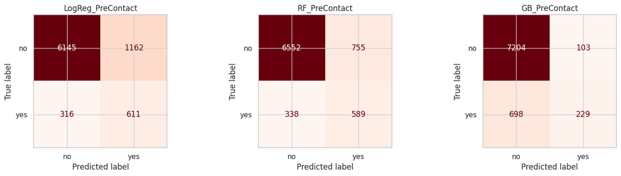

```python
# matrices de confusion - modeles pre-contact

from sklearn.metrics import ConfusionMatrixDisplay

fig, axes = plt.subplots(1, 3, figsize=(15, 4))
for ax, name in zip(axes, ['LogReg_PreContact', 'RF_PreContact', 'GB_PreContact']):
    pred = fitted[name].predict(test_df[models[name][1]])
    cm = confusion_matrix(y_test, pred)
    ConfusionMatrixDisplay(cm, display_labels=['no', 'yes']).plot(ax=ax, cmap='Reds', colorbar=False)
    ax.set_title(name)

plt.tight_layout()
plt.savefig('at3_confusion.png', dpi=150, bbox_inches='tight')
plt.show()
```

# Top-K targeting analysis

```python
# Top-K targeting (modeles pre-contact)
# si on contacte K% des clients tries par proba decroissante, combien de souscripteurs on attrape ?

pre_models = ['LogReg_PreContact', 'RF_PreContact', 'GB_PreContact']
ks = [0.05, 0.10, 0.15, 0.20, 0.25, 0.30, 0.50]

rows = []
total_subs = y_test.sum()
baseline_rate = y_test.mean()

for name in pre_models:
    feats = models[name][1]
    proba = fitted[name].predict_proba(test_df[feats])[:, 1]
    order = np.argsort(-proba)
    y_sorted = y_test.values[order]

    for k in ks:
        n_contacted = int(k * len(y_test))
        subs_caught = y_sorted[:n_contacted].sum()
        recall_k = subs_caught / total_subs
        precision_k = subs_caught / n_contacted
        lift = precision_k / baseline_rate
        rows.append({
            'Model': name,
            'K (%)': int(k * 100),
            'Customers contacted': n_contacted,
            'Subscribers caught': subs_caught,
            'Recall@K': round(recall_k, 3),
            'Conversion rate': round(precision_k, 3),
            'Lift vs baseline': round(lift, 2),
        })

topk_df = pd.DataFrame(rows)
print(f'Baseline conversion rate (random) : {baseline_rate:.3f}')
print(f'Total subscribers in test set : {total_subs}')
topk_df
```

```
Baseline conversion rate (random) : 0.113
Total subscribers in test set : 927
```

|  | Model | K (%) | Customers contacted | Subscribers caught | Recall@K | Conversion rate | Lift vs baseline |
| --- | --- | --- | --- | --- | --- | --- | --- |
| 0 | LogReg_PreContact | 5 | 411 | 252 | 0.27 | 0.61 | 5.45 |
| 1 | LogReg_PreContact | 10 | 823 | 408 | 0.44 | 0.50 | 4.40 |
| 2 | LogReg_PreContact | 15 | 1235 | 555 | 0.60 | 0.45 | 3.99 |
| 3 | LogReg_PreContact | 20 | 1646 | 594 | 0.64 | 0.36 | 3.21 |
| 4 | LogReg_PreContact | 25 | 2058 | 637 | 0.69 | 0.31 | 2.75 |
| 5 | LogReg_PreContact | 30 | 2470 | 668 | 0.72 | 0.27 | 2.40 |
| 6 | LogReg_PreContact | 50 | 4117 | 763 | 0.82 | 0.18 | 1.65 |
| 7 | RF_PreContact | 5 | 411 | 266 | 0.29 | 0.65 | 5.75 |
| 8 | RF_PreContact | 10 | 823 | 440 | 0.47 | 0.54 | 4.75 |
| 9 | RF_PreContact | 15 | 1235 | 575 | 0.62 | 0.47 | 4.14 |
| 10 | RF_PreContact | 20 | 1646 | 617 | 0.67 | 0.38 | 3.33 |
| 11 | RF_PreContact | 25 | 2058 | 654 | 0.71 | 0.32 | 2.82 |
| 12 | RF_PreContact | 30 | 2470 | 683 | 0.74 | 0.28 | 2.46 |
| 13 | RF_PreContact | 50 | 4117 | 781 | 0.84 | 0.19 | 1.69 |
| 14 | GB_PreContact | 5 | 411 | 267 | 0.29 | 0.65 | 5.77 |
| 15 | GB_PreContact | 10 | 823 | 435 | 0.47 | 0.53 | 4.69 |
| 16 | GB_PreContact | 15 | 1235 | 576 | 0.62 | 0.47 | 4.14 |
| 17 | GB_PreContact | 20 | 1646 | 623 | 0.67 | 0.38 | 3.36 |
| 18 | GB_PreContact | 25 | 2058 | 657 | 0.71 | 0.32 | 2.84 |
| 19 | GB_PreContact | 30 | 2470 | 695 | 0.75 | 0.28 | 2.50 |
| 20 | GB_PreContact | 50 | 4117 | 784 | 0.85 | 0.19 | 1.69 |

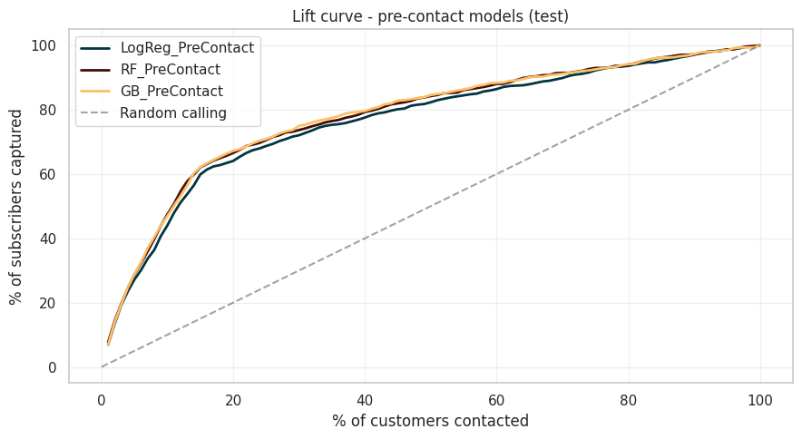

```python
# lift curve

fig, ax = plt.subplots(figsize=(9, 5))
model_colors_pre = {'LogReg_PreContact': colors[4],
                    'RF_PreContact':     colors[0],
                    'GB_PreContact':     colors[2]}

ks_fine = np.arange(0.01, 1.01, 0.01)
for name in pre_models:
    feats = models[name][1]
    proba = fitted[name].predict_proba(test_df[feats])[:, 1]
    order = np.argsort(-proba)
    y_sorted = y_test.values[order]

    recalls = [y_sorted[:int(k * len(y_test))].sum() / total_subs for k in ks_fine]
    ax.plot(ks_fine * 100, np.array(recalls) * 100,
            label=name, color=model_colors_pre[name], linewidth=2)

ax.plot([0, 100], [0, 100], 'k--', alpha=0.4, label='Random calling')

ax.set_xlabel('% of customers contacted')
ax.set_ylabel('% of subscribers captured')
ax.set_title('Lift curve - pre-contact models (test)')
ax.legend()
ax.grid(alpha=0.3)
plt.tight_layout()
plt.savefig('at3_lift_curve.png', dpi=150, bbox_inches='tight')
plt.show()
```